# *Milestone 1*

## Step 1: Import the data

```python
import sys
!{sys.executable} -m pip install pandas-profiling
```

[output not shown]

```python
import pandas as pd
pd.set_option('display.max_columns', None)
pd.set_option('display.max_rows', None)
import numpy as np
from pandas_profiling import ProfileReport
import re
import os

import nltk
nltk.download('punkt')
nltk.download('stopwords')
nltk.download('wordnet', quiet=True) # wordnet library
nltk.download('words', quiet=True) # words library
nltk.download('omw-1.4')
from nltk.corpus import stopwords
from nltk.tokenize import word_tokenize
from nltk.stem.wordnet import WordNetLemmatizer

from imblearn.over_sampling import RandomOverSampler

from sklearn.metrics import accuracy_score
from sklearn.metrics import roc_auc_score
from sklearn.metrics import f1_score,recall_score, precision_score

from sklearn.svm import SVC
from sklearn.neighbors import KNeighborsClassifier
from sklearn.ensemble import RandomForestClassifier
from sklearn.ensemble import GradientBoostingClassifier
from sklearn.ensemble import AdaBoostClassifier
from sklearn.tree import DecisionTreeClassifier
from sklearn.linear_model import LogisticRegression

from scipy.stats import randint as sp_randint
from scipy.stats import uniform as sp_uniform


from sklearn.preprocessing import StandardScaler
from sklearn.preprocessing import LabelEncoder
from sklearn.decomposition import PCA

from sklearn.model_selection import train_test_split

from sklearn.model_selection import GridSearchCV
from sklearn.model_selection import RandomizedSearchCV

import matplotlib.pyplot as plt
import seaborn as sns
sns.set(rc={'figure.figsize':(11.7,8.27)})

import warnings
warnings.filterwarnings('ignore')

from keras.models import Model
from tensorflow.keras.preprocessing.text import Tokenizer
from tensorflow.keras.preprocessing.sequence import pad_sequences
from keras.utils.np_utils import to_categorical

import tensorflow as tf
import keras
from keras.models import Sequential
from keras.optimizers import SGD,Adam
from keras.layers import Input
from keras.layers import Layer
from keras import backend as K
import pickle
from tensorflow.keras.layers import  Flatten, Activation, Dense, LSTM, BatchNormalization, Embedding, Dropout, Flatten, Bidirectional, GlobalMaxPool1D
```

```python
from google.colab import drive
drive.mount('/content/drive')
path = '/content/drive/MyDrive/Data Set - industrial_safety_and_health_database_with_accidents_description.csv'
```

```python
data = pd.read_csv(path)
```

## Step 2: Data cleansing

```python
data.head(5)
```

|  | Unnamed: 0 | Data | Countries | Local | Industry Sector | Accident Level | Potential Accident Level | Genre | Employee or Third Party | Critical Risk | Description |
| --- | --- | --- | --- | --- | --- | --- | --- | --- | --- | --- | --- |
| 0 | 0 | 2016-01-01 00:00:00 | Country_01 | Local_01 | Mining | I | IV | Male | Third Party | Pressed | While removing the drill rod of the Jumbo 08 f... |
| 1 | 1 | 2016-01-02 00:00:00 | Country_02 | Local_02 | Mining | I | IV | Male | Employee | Pressurized Systems | During the activation of a sodium sulphide pum... |
| 2 | 2 | 2016-01-06 00:00:00 | Country_01 | Local_03 | Mining | I | III | Male | Third Party (Remote) | Manual Tools | In the sub-station MILPO located at level +170... |
| 3 | 3 | 2016-01-08 00:00:00 | Country_01 | Local_04 | Mining | I | I | Male | Third Party | Others | Being 9:45 am. approximately in the Nv. 1880 C... |
| 4 | 4 | 2016-01-10 00:00:00 | Country_01 | Local_04 | Mining | IV | IV | Male | Third Party | Others | Approximately at 11:45 a.m. in circumstances t... |

```
 Columns named Countries, Local, Industry Sector, Accident Level, Potential Accident Level, Genre, Employee or Third Party, Critical Risk are categorical columns.
 Description is text column.
 Data is DateTime column.
```

```python
data.info()
```

```
<class 'pandas.core.frame.DataFrame'>
RangeIndex: 425 entries, 0 to 424
Data columns (total 11 columns):
 #   Column                    Non-Null Count  Dtype
---  ------                    --------------  -----
 0   Unnamed: 0                425 non-null    int64
 1   Data                      425 non-null    object
 2   Countries                 425 non-null    object
 3   Local                     425 non-null    object
 4   Industry Sector           425 non-null    object
 5   Accident Level            425 non-null    object
 6   Potential Accident Level  425 non-null    object
 7   Genre                     425 non-null    object
 8   Employee or Third Party   425 non-null    object
 9   Critical Risk             425 non-null    object
 10  Description               425 non-null    object
dtypes: int64(1), object(10)
memory usage: 36.6+ KB
```

```
 All columns except Unnamed: 0 are of object type.
```

```python
dataset=data.drop_duplicates()
```

```python
dataset.shape
```

```
(425, 11)
```

```
There are total 425 rows and 11 columns.
```

```python
dataset.drop('Unnamed: 0',axis=1,inplace=True)
```

```python
dataset.head(10)
```

|  | Data | Countries | Local | Industry Sector | Accident Level | Potential Accident Level | Genre | Employee or Third Party | Critical Risk | Description |
| --- | --- | --- | --- | --- | --- | --- | --- | --- | --- | --- |
| 0 | 2016-01-01 00:00:00 | Country_01 | Local_01 | Mining | I | IV | Male | Third Party | Pressed | While removing the drill rod of the Jumbo 08 f... |
| 1 | 2016-01-02 00:00:00 | Country_02 | Local_02 | Mining | I | IV | Male | Employee | Pressurized Systems | During the activation of a sodium sulphide pum... |
| 2 | 2016-01-06 00:00:00 | Country_01 | Local_03 | Mining | I | III | Male | Third Party (Remote) | Manual Tools | In the sub-station MILPO located at level +170... |
| 3 | 2016-01-08 00:00:00 | Country_01 | Local_04 | Mining | I | I | Male | Third Party | Others | Being 9:45 am. approximately in the Nv. 1880 C... |
| 4 | 2016-01-10 00:00:00 | Country_01 | Local_04 | Mining | IV | IV | Male | Third Party | Others | Approximately at 11:45 a.m. in circumstances t... |
| 5 | 2016-01-12 00:00:00 | Country_02 | Local_05 | Metals | I | III | Male | Third Party (Remote) | Pressurized Systems | During the unloading operation of the ustulado... |
| 6 | 2016-01-16 00:00:00 | Country_02 | Local_05 | Metals | I | III | Male | Employee | Fall prevention (same level) | The collaborator reports that he was on street... |
| 7 | 2016-01-17 00:00:00 | Country_01 | Local_04 | Mining | I | III | Male | Third Party | Pressed | At approximately 04:50 p.m., when the mechanic... |
| 8 | 2016-01-19 00:00:00 | Country_02 | Local_02 | Mining | I | IV | Male | Third Party (Remote) | Others | Employee was sitting in the resting area at le... |
| 9 | 2016-01-26 00:00:00 | Country_01 | Local_06 | Metals | I | II | Male | Third Party | Chemical substances | At the moment the forklift operator went to ma... |

```
Dropped 'Unnamed: 0' column as it was just column index not required.
```

```python
dataset.isnull().sum()
```

```
Data                        0
Countries                   0
Local                       0
Industry Sector             0
Accident Level              0
Potential Accident Level    0
Genre                       0
Employee or Third Party     0
Critical Risk               0
Description                 0
dtype: int64
```

```
There are no null values found in column.
```

```python
print('Countries unique values:',dataset.Countries.unique())
print('Local unique values:',dataset.Local.unique())
print('Industry Sector unique values:',dataset['Industry Sector'].unique())
print('Accident Level unique values:',dataset['Accident Level'].unique())
print('Potential Accident Level unique values:',dataset['Potential Accident Level'].unique())
print('Genre unique values:',dataset['Genre'].unique())
print('Employee or Third Party unique values:',dataset['Employee or Third Party'].unique())
print('Critical Risk unique values:',dataset['Critical Risk'].unique())
print('Data unique values:',dataset['Data'].unique())
```

```
Countries unique values: ['Country_01' 'Country_02' 'Country_03']
Local unique values: ['Local_01' 'Local_02' 'Local_03' 'Local_04' 'Local_05' 'Local_06'
 'Local_07' 'Local_08' 'Local_10' 'Local_09' 'Local_11' 'Local_12']
Industry Sector unique values: ['Mining' 'Metals' 'Others']
Accident Level unique values: ['I' 'IV' 'III' 'II' 'V']
Potential Accident Level unique values: ['IV' 'III' 'I' 'II' 'V' 'VI']
Genre unique values: ['Male' 'Female']
Employee or Third Party unique values: ['Third Party' 'Employee' 'Third Party (Remote)']
Critical Risk unique values: ['Pressed' 'Pressurized Systems' 'Manual Tools' 'Others'
 'Fall prevention (same level)' 'Chemical substances' 'Liquid Metal'
 'Electrical installation' 'Confined space'
 'Pressurized Systems / Chemical Substances'
 'Blocking and isolation of energies' 'Suspended Loads' 'Poll' 'Cut'
 'Fall' 'Bees' 'Fall prevention' '\nNot applicable' 'Traffic' 'Projection'
 'Venomous Animals' 'Plates' 'Projection/Burning' 'remains of choco'
 'Vehicles and Mobile Equipment' 'Projection/Choco' 'Machine Protection'
 'Power lock' 'Burn' 'Projection/Manual Tools'
 'Individual protection equipment' 'Electrical Shock'
 'Projection of fragments']
Data unique values: ['2016-01-01 00:00:00' '2016-01-02 00:00:00' '2016-01-06 00:00:00'
 '2016-01-08 00:00:00' '2016-01-10 00:00:00' '2016-01-12 00:00:00'
 '2016-01-16 00:00:00' '2016-01-17 00:00:00' '2016-01-19 00:00:00'
 '2016-01-26 00:00:00' '2016-01-28 00:00:00' '2016-01-30 00:00:00'
 '2016-02-01 00:00:00' '2016-02-02 00:00:00' '2016-02-04 00:00:00'
 '2016-02-06 00:00:00' '2016-02-07 00:00:00' '2016-02-08 00:00:00'
 '2016-02-21 00:00:00' '2016-02-25 00:00:00' '2016-02-09 00:00:00'
 '2016-02-10 00:00:00' '2016-02-15 00:00:00' '2016-02-14 00:00:00'
 '2016-02-13 00:00:00' '2016-02-16 00:00:00' '2016-02-17 00:00:00'
 '2016-02-19 00:00:00' '2016-02-20 00:00:00' '2016-02-18 00:00:00'
 '2016-02-22 00:00:00' '2016-02-24 00:00:00' '2016-02-29 00:00:00'
 '2016-02-26 00:00:00' '2016-02-27 00:00:00' '2016-03-02 00:00:00'
 '2016-03-03 00:00:00' '2016-03-04 00:00:00' '2016-03-05 00:00:00'
 '2016-03-06 00:00:00' '2016-03-09 00:00:00' '2016-03-11 00:00:00'
 '2016-03-13 00:00:00' '2016-03-12 00:00:00' '2016-03-14 00:00:00'
 '2016-03-16 00:00:00' '2016-03-10 00:00:00' '2016-03-17 00:00:00'
 '2016-03-18 00:00:00' '2016-03-19 00:00:00' '2016-03-22 00:00:00'
 '2016-03-25 00:00:00' '2016-03-30 00:00:00' '2016-03-31 00:00:00'
 '2016-04-01 00:00:00' '2016-04-03 00:00:00' '2016-04-02 00:00:00'
 '2016-03-24 00:00:00' '2016-04-04 00:00:00' '2016-04-05 00:00:00'
 '2016-04-07 00:00:00' '2016-04-08 00:00:00' '2016-04-11 00:00:00'
```

[output cut: 60 more lines]

```
 '2017-03-25 00:00:00' '2017-03-31 00:00:00' '2017-04-04 00:00:00'
 '2017-04-05 00:00:00' '2017-04-07 00:00:00' '2017-04-06 00:00:00'
 '2017-04-10 00:00:00' '2017-04-08 00:00:00' '2017-04-11 00:00:00'
 '2017-04-13 00:00:00' '2017-04-12 00:00:00' '2017-04-23 00:00:00'
 '2017-04-19 00:00:00' '2017-04-25 00:00:00' '2017-04-24 00:00:00'
 '2017-04-28 00:00:00' '2017-04-29 00:00:00' '2017-04-30 00:00:00'
 '2017-05-05 00:00:00' '2017-05-06 00:00:00' '2017-05-10 00:00:00'
 '2017-05-16 00:00:00' '2017-05-17 00:00:00' '2017-05-18 00:00:00'
 '2017-05-19 00:00:00' '2017-05-23 00:00:00' '2017-05-30 00:00:00'
 '2017-06-04 00:00:00' '2017-06-09 00:00:00' '2017-06-11 00:00:00'
 '2017-06-14 00:00:00' '2017-06-15 00:00:00' '2017-06-17 00:00:00'
 '2017-06-18 00:00:00' '2017-06-24 00:00:00' '2017-06-20 00:00:00'
 '2017-06-23 00:00:00' '2017-06-19 00:00:00' '2017-06-22 00:00:00'
 '2017-06-29 00:00:00' '2017-07-04 00:00:00' '2017-07-05 00:00:00'
 '2017-07-06 00:00:00' '2017-07-09 00:00:00']
```

```
All columns have unique values, but one of the value in critical risk is 'Not Applicable' we can remove that row.
```

```python
dataset = dataset[dataset['Critical Risk'] != '\nNot applicable']
dataset['Critical Risk'].unique()
```

```
array(['Pressed', 'Pressurized Systems', 'Manual Tools', 'Others',
       'Fall prevention (same level)', 'Chemical substances',
       'Liquid Metal', 'Electrical installation', 'Confined space',
       'Pressurized Systems / Chemical Substances',
       'Blocking and isolation of energies', 'Suspended Loads', 'Poll',
       'Cut', 'Fall', 'Bees', 'Fall prevention', 'Traffic', 'Projection',
       'Venomous Animals', 'Plates', 'Projection/Burning',
       'remains of choco', 'Vehicles and Mobile Equipment',
       'Projection/Choco', 'Machine Protection', 'Power lock', 'Burn',
       'Projection/Manual Tools', 'Individual protection equipment',
       'Electrical Shock', 'Projection of fragments'], dtype=object)
```

```python
dataset.shape
```

```
(424, 10)
```

```
Now we have 424 rows and 10 columns left.
```

```python
dataset.head(10)
```

|  | Data | Countries | Local | Industry Sector | Accident Level | Potential Accident Level | Genre | Employee or Third Party | Critical Risk | Description |
| --- | --- | --- | --- | --- | --- | --- | --- | --- | --- | --- |
| 0 | 2016-01-01 00:00:00 | Country_01 | Local_01 | Mining | I | IV | Male | Third Party | Pressed | While removing the drill rod of the Jumbo 08 f... |
| 1 | 2016-01-02 00:00:00 | Country_02 | Local_02 | Mining | I | IV | Male | Employee | Pressurized Systems | During the activation of a sodium sulphide pum... |
| 2 | 2016-01-06 00:00:00 | Country_01 | Local_03 | Mining | I | III | Male | Third Party (Remote) | Manual Tools | In the sub-station MILPO located at level +170... |
| 3 | 2016-01-08 00:00:00 | Country_01 | Local_04 | Mining | I | I | Male | Third Party | Others | Being 9:45 am. approximately in the Nv. 1880 C... |
| 4 | 2016-01-10 00:00:00 | Country_01 | Local_04 | Mining | IV | IV | Male | Third Party | Others | Approximately at 11:45 a.m. in circumstances t... |
| 5 | 2016-01-12 00:00:00 | Country_02 | Local_05 | Metals | I | III | Male | Third Party (Remote) | Pressurized Systems | During the unloading operation of the ustulado... |
| 6 | 2016-01-16 00:00:00 | Country_02 | Local_05 | Metals | I | III | Male | Employee | Fall prevention (same level) | The collaborator reports that he was on street... |
| 7 | 2016-01-17 00:00:00 | Country_01 | Local_04 | Mining | I | III | Male | Third Party | Pressed | At approximately 04:50 p.m., when the mechanic... |
| 8 | 2016-01-19 00:00:00 | Country_02 | Local_02 | Mining | I | IV | Male | Third Party (Remote) | Others | Employee was sitting in the resting area at le... |
| 9 | 2016-01-26 00:00:00 | Country_01 | Local_06 | Metals | I | II | Male | Third Party | Chemical substances | At the moment the forklift operator went to ma... |

```python
dataset.rename(columns={'Data':'Date', 'Countries':'Country', 'Genre':'Gender', 'Employee or Third Party':'Employee type'}, inplace=True)
# Convert the timestamp column to datetime
dataset['Date'] = pd.to_datetime(dataset['Date'])

# Create a new column for seasons
dataset['Season'] = (dataset['Date'].dt.month%12 + 3)//3
season_dict = {1: 'Winter', 2: 'Spring', 3: 'Summer', 4: 'Fall'}
dataset['Season'] = dataset['Season'].map(season_dict)
dataset['Date'] = pd.to_datetime(dataset['Date'])

# Define a function to extract the segments
def extract_segment(dt_obj):
    year = dt_obj.year
    month = dt_obj.month
    week = dt_obj.isocalendar()[1]
    day = dt_obj.day
    hour = dt_obj.hour
    return pd.Series([year, month, week, day, hour])

# Apply the function to the date column
dataset[['Year', 'Month', 'Week', 'Day', 'Hour']] = dataset['Date'].apply(extract_segment)

dataset['Weekday'] = dataset['Date'].apply(lambda x: x.day_name())
```

```python
dataset.head(5)
```

|  | Date | Country | Local | Industry Sector | Accident Level | Potential Accident Level | Gender | Employee type | Critical Risk | Description | Season | Year | Month | Week | Day | Hour | Weekday |
| --- | --- | --- | --- | --- | --- | --- | --- | --- | --- | --- | --- | --- | --- | --- | --- | --- | --- |
| 0 | 2016-01-01 | Country_01 | Local_01 | Mining | I | IV | Male | Third Party | Pressed | While removing the drill rod of the Jumbo 08 f... | Winter | 2016 | 1 | 53 | 1 | 0 | Friday |
| 1 | 2016-01-02 | Country_02 | Local_02 | Mining | I | IV | Male | Employee | Pressurized Systems | During the activation of a sodium sulphide pum... | Winter | 2016 | 1 | 53 | 2 | 0 | Saturday |
| 2 | 2016-01-06 | Country_01 | Local_03 | Mining | I | III | Male | Third Party (Remote) | Manual Tools | In the sub-station MILPO located at level +170... | Winter | 2016 | 1 | 1 | 6 | 0 | Wednesday |
| 3 | 2016-01-08 | Country_01 | Local_04 | Mining | I | I | Male | Third Party | Others | Being 9:45 am. approximately in the Nv. 1880 C... | Winter | 2016 | 1 | 1 | 8 | 0 | Friday |
| 4 | 2016-01-10 | Country_01 | Local_04 | Mining | IV | IV | Male | Third Party | Others | Approximately at 11:45 a.m. in circumstances t... | Winter | 2016 | 1 | 1 | 10 | 0 | Sunday |

```python
# Generating data profile for the dataset
profile = ProfileReport(dataset, title="industrial-safety-and-health-analytics-database data profile")
profile.to_widgets()
```

```python
profile.to_file(output_file="pandas_profiling1.html")
```

**EDA**

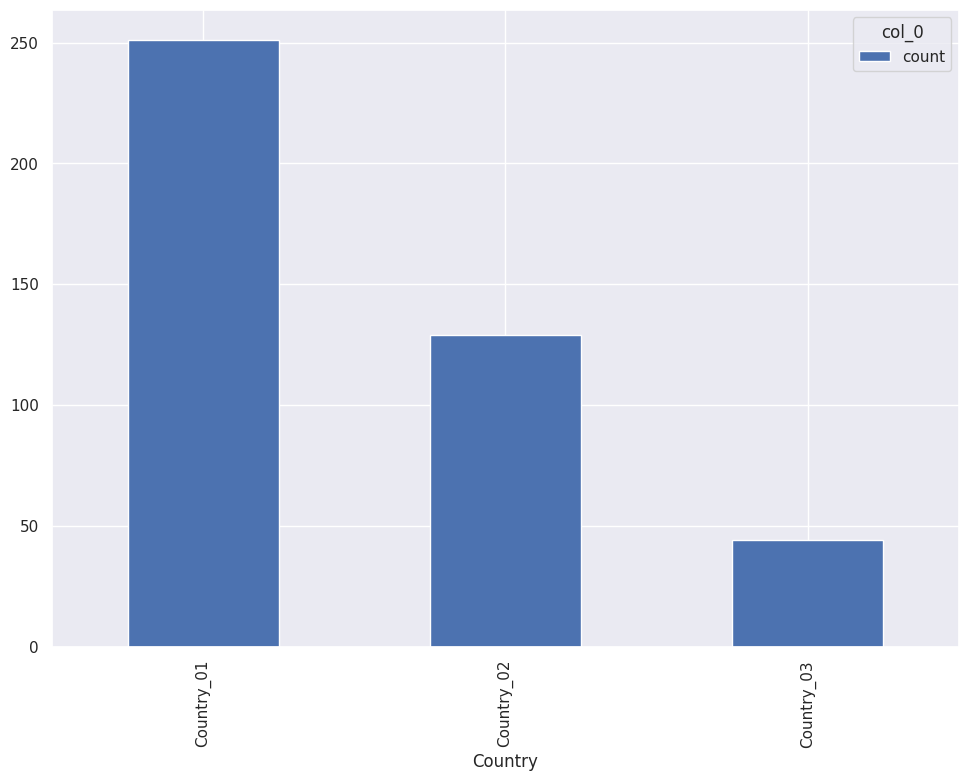

```python
country_tab = pd.crosstab(index = dataset["Country"],
                              columns="count")
country_tab.plot.bar()
```

```
Country_01 seems to have largest accident occured, then Country_02 and very less accidents in Country_03
```

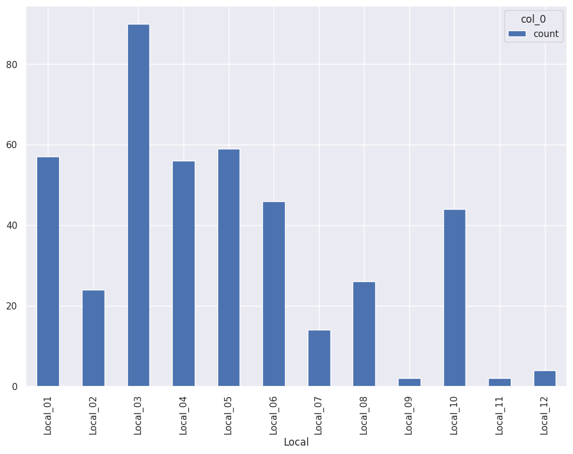

```python
city_tab = pd.crosstab(index = dataset["Local"],
                              columns="count")
city_tab.plot.bar()
```

```
Local_03 city is the highest accident prone area
Local_01,Local_04,Local_05 also have second largest contribution to accidents.
Local_06 and Local_10 have third largest contribution to accidents.
```

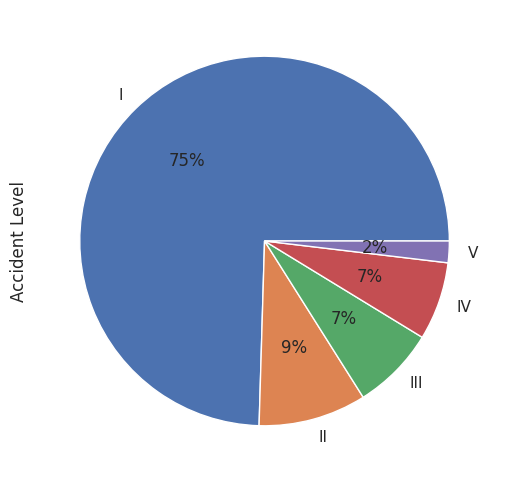

```python
dataset['Accident Level'].value_counts().plot(kind = 'pie', autopct = '%.0f%%', labels = ['I', 'II', 'III','IV','V','V1'], figsize = (10, 6))
```

```
Accident Level I has highest percentage.
```

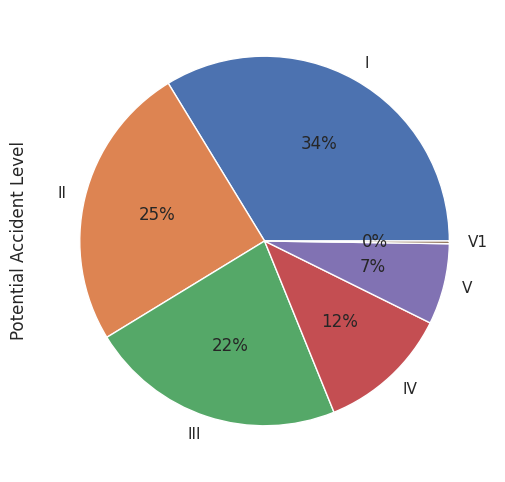

```python
dataset['Potential Accident Level'].value_counts().plot(kind = 'pie', autopct = '%.0f%%', labels = ['I', 'II', 'III','IV','V','V1'], figsize = (10, 6))
```

[output not shown]

```python
dataset['Industry Sector'].value_counts()
```

```
Mining    241
Metals    133
Others     50
Name: Industry Sector, dtype: int64
```

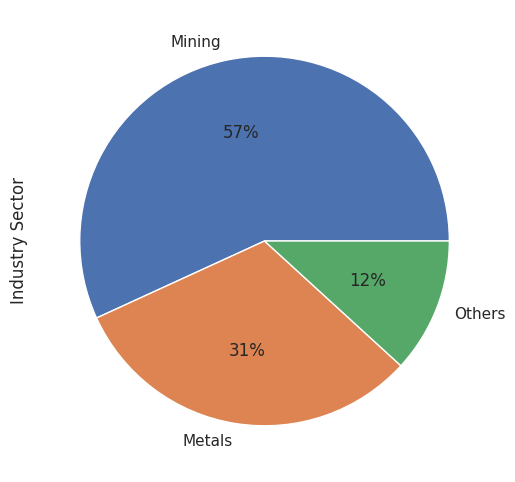

```python
dataset['Industry Sector'].value_counts().plot(kind = 'pie', autopct = '%.0f%%', labels = ['Mining', 'Metals' ,'Others'], figsize = (10, 6))
```

```
1. Mining Sector is prone to highest accidents.
2. Metals Sector has second highest accidents
```

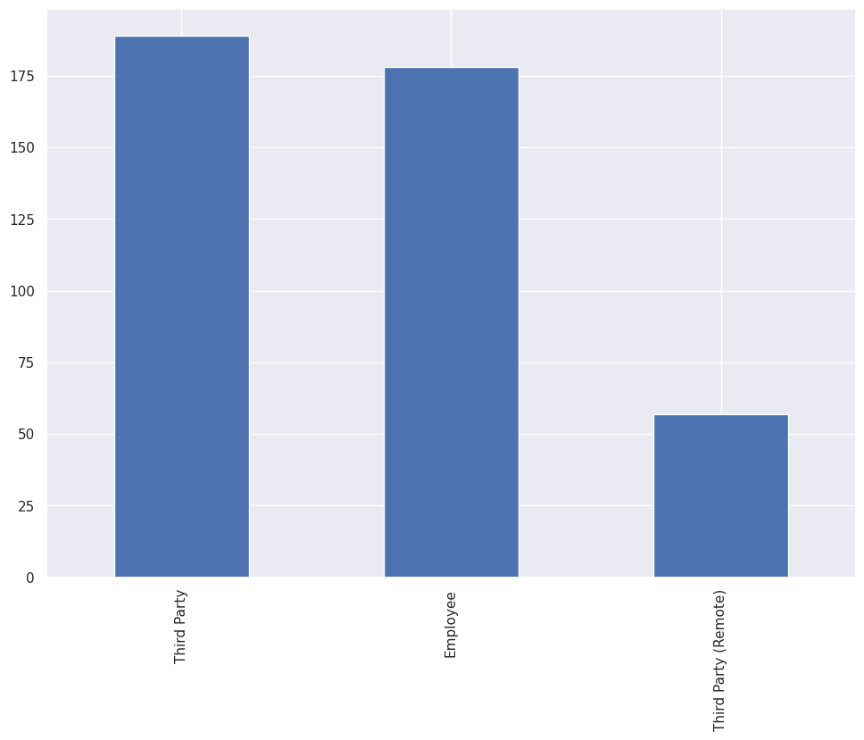

```python
dataset['Employee type'].value_counts().plot.bar()
```

```
1. Third Party is prone to more accidents than Employee.
```

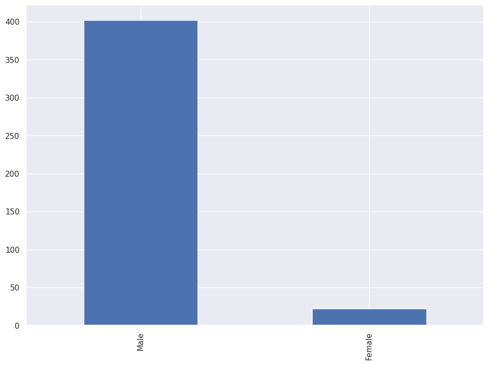

```python
dataset['Gender'].value_counts().plot.bar()
```

```
Males are prone to more accidents than female.
```

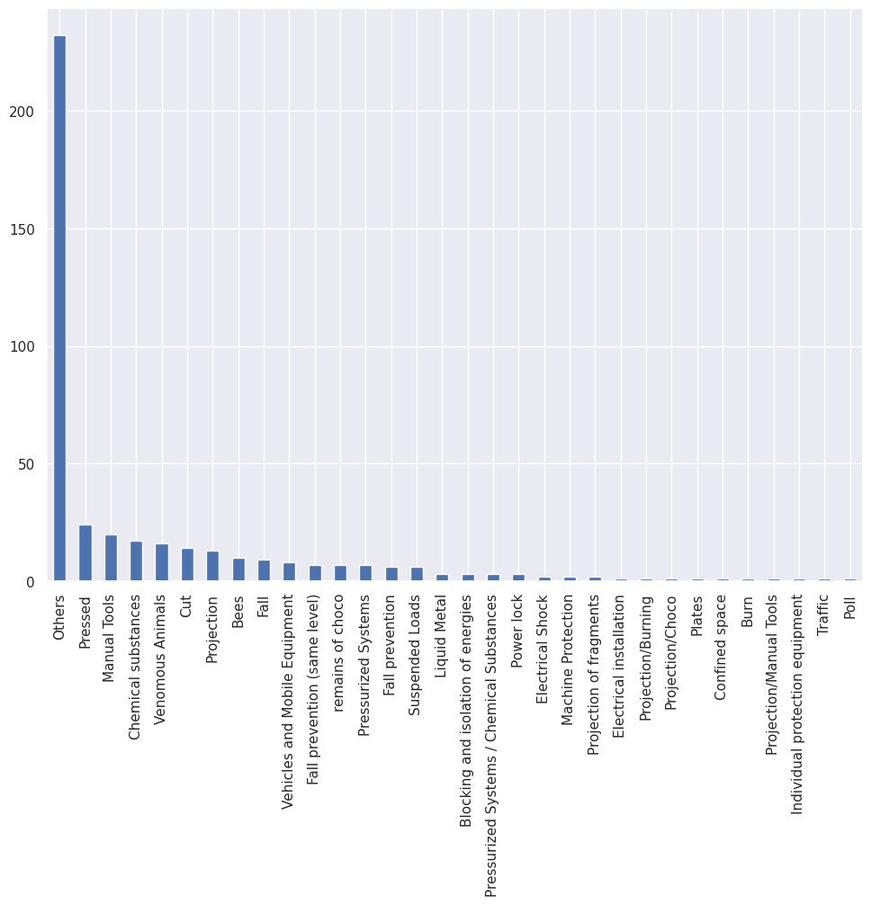

```python
dataset['Critical Risk'].value_counts().plot.bar()
```

```
Others category of critical risk have more accidents.
```

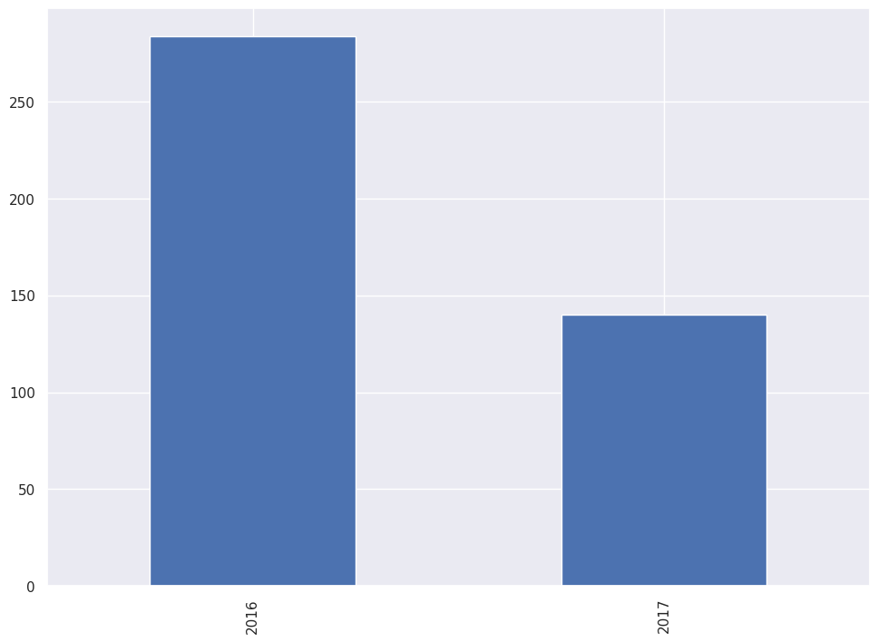

```python
dataset['Year'].value_counts().plot.bar()
```

```
Year 2016 have more accidents comparetively 2017
```

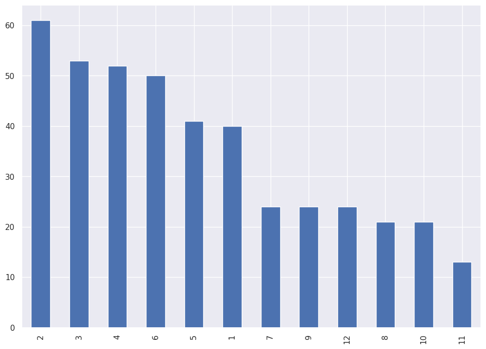

```python
dataset['Month'].value_counts().plot.bar()
```

```
Feburary month have more accidents
After Feburary, March, April and June have more accidents.
```

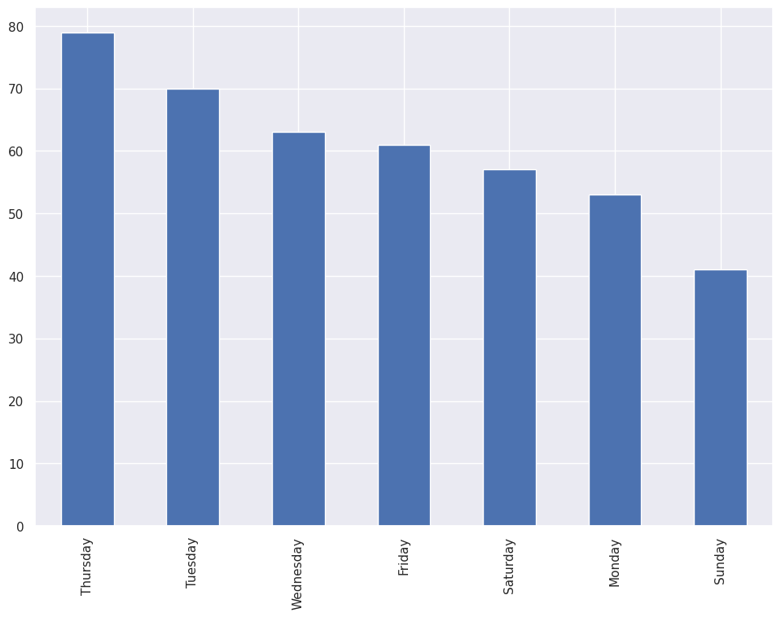

```python
dataset['Weekday'].value_counts().plot.bar()
```

```
Thursday and then Tuesday have more accidents compared to other day of week.
```

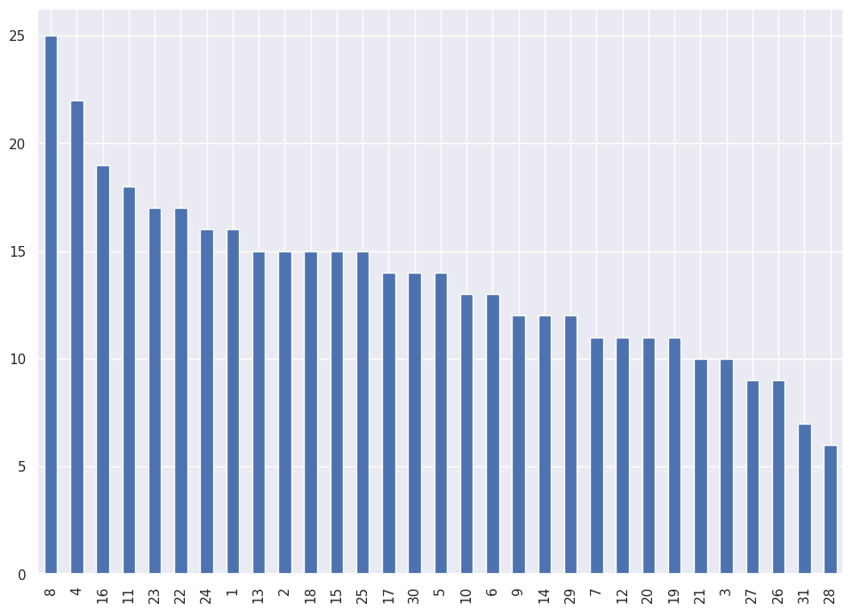

```python
dataset['Day'].value_counts().plot.bar()
```

```
Day 8 and 4 seems to have more accidents.
After that Day 16 and 11 seems to have more accidents.
```

```
Potential Accident Level   I  II  III   IV   V  VI
Country
Country_01                10  51   64  103  22   1
Country_02                 7  40   41   33   8   0
Country_03                32   4    1    7   0   0
```

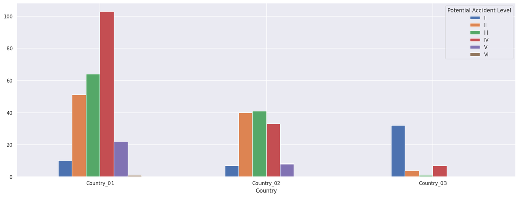

```python
CrosstabResult=pd.crosstab(index=dataset['Country'],columns=dataset['Potential Accident Level'])
print(CrosstabResult)
CrosstabResult.plot.bar(figsize=(20,7), rot=0)
```

```
Country_01 seems to have more Level IV potential accidents.
Country_02, seems to have more Level II and Level III potential accidents
Country_03, seems to have more Level I potential accidents.
```

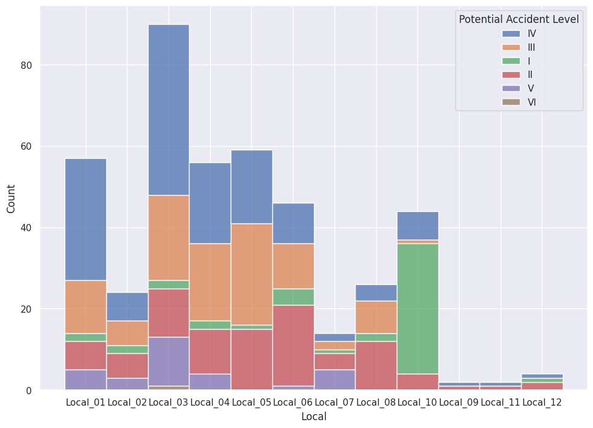

```python
sns.histplot(binwidth=0.9, x="Local", hue="Potential Accident Level", data=dataset, stat="count", multiple="stack")
```

```
Local_03 have more Level IV potential accidents
Local_09 and Local_11 have very less number of potential accident levels.
Level VI potential accident is visible only in Local_03
```

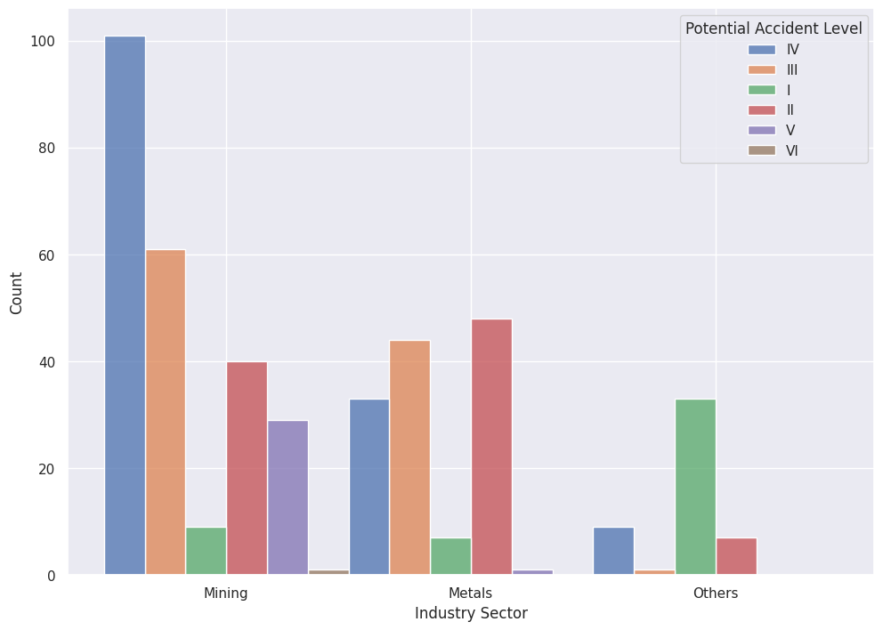

```python
sns.histplot(binwidth=1,
            x="Industry Sector",
            hue="Potential Accident Level",
            data=dataset,
            stat="count",
            multiple="dodge")
```

```
Mining industry is facing lot of Level IV potential accident level
Metals Industry is facing lot of Level II potential accident level
Others Industry is facing lot of Level I potential accident level
```

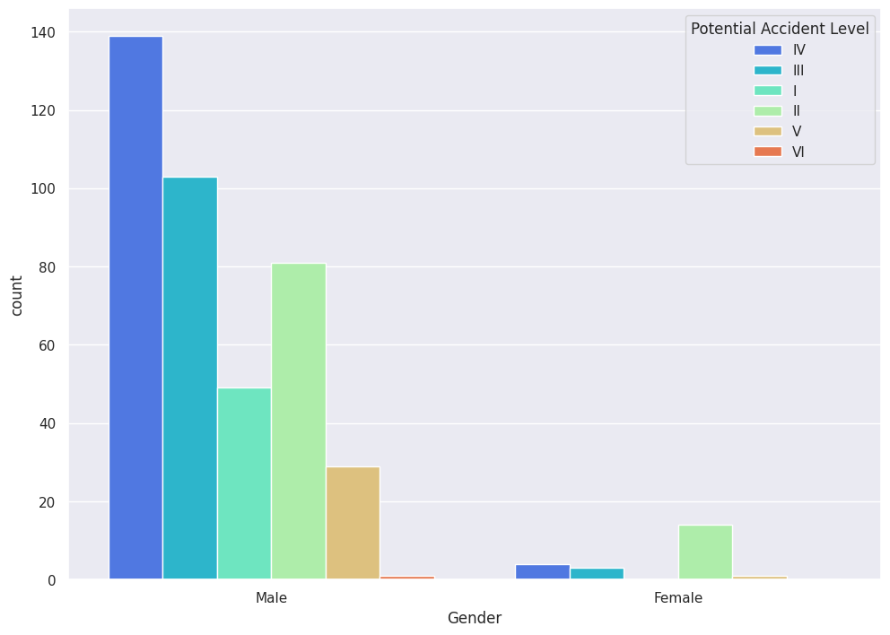

```python
sns.countplot(x='Gender',data=dataset, palette='rainbow',hue='Potential Accident Level')
```

```
Male employees met with accidents more and that too of Level IV.
Female employees met with accident Level of II mostly.
```

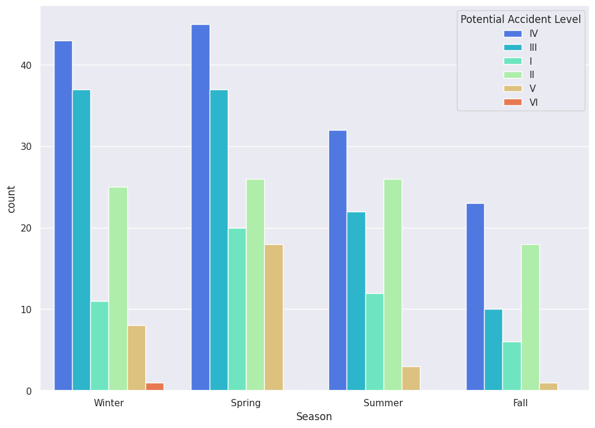

```python
sns.countplot(x='Season',data=dataset, palette='rainbow',hue='Potential Accident Level')
```

Accident Level IV were the maximum occurring throughout all seasons.

```
Potential Accident Level   I  II  III  IV   V  VI
Employee type
Employee                  12  44   53  59  10   0
Third Party               32  37   35  69  15   1
Third Party (Remote)       5  14   18  15   5   0
```

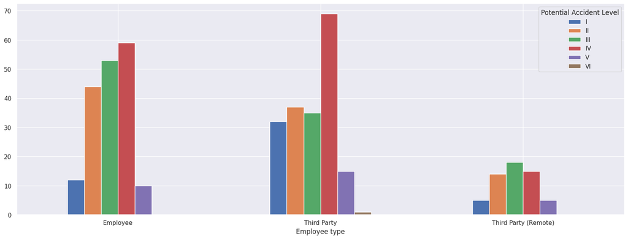

```python
CrosstabResult=pd.crosstab(index=dataset['Employee type'],columns=dataset['Potential Accident Level'])
print(CrosstabResult)
CrosstabResult.plot.bar(figsize=(20,7), rot=0)
```

```
Level II, III accident are borne more by Employee than Third Party.
But Level I, Level IV , Level V and Level VI accidents happened more to Third Party than to Employee
```

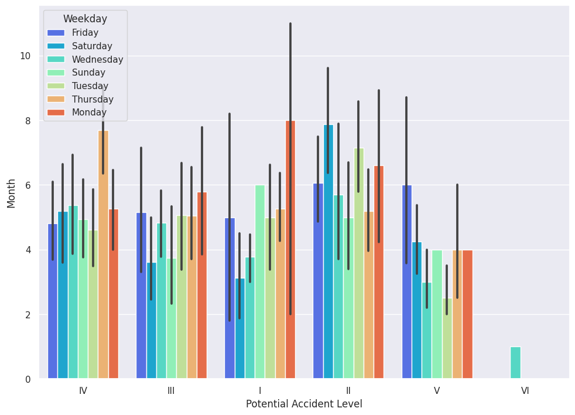

```python
sns.barplot(x='Potential Accident Level',y='Month',data=dataset, palette='rainbow', hue='Weekday')
```

[output not shown]

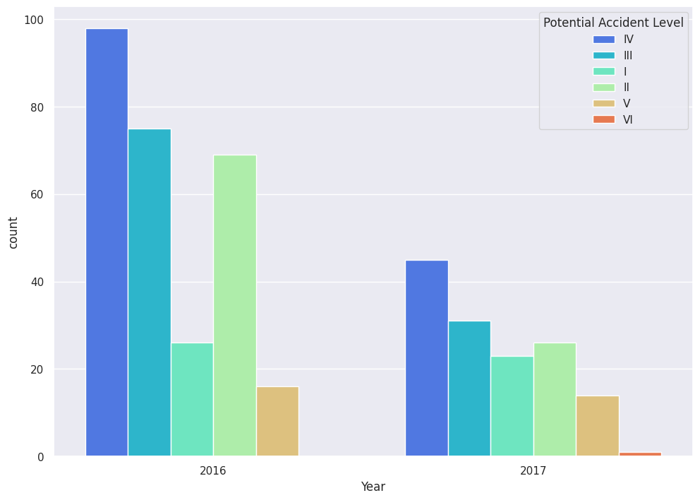

```python
sns.countplot(x='Year',data=dataset, palette='rainbow',hue='Potential Accident Level')
```

```
2016 had most of potential accidents and that too of Level IV
```

## Step 3: Data preprocessing

```python
!pip install langdetect
```

```
     ━━━━━━━━━━━━━━━━━━━━━━━━━━━━━━━━━━━━━━ 981.5/981.5 kB 22.0 MB/s eta 0:00:00
  Preparing metadata (setup.py) ... done
```

```python
from langdetect import detect

def detect_english(text):
  try:
      return detect(text) == 'en'
  except:
      return False
```

```python
df = dataset
df.head(5)
```

|  | Date | Country | Local | Industry Sector | Accident Level | Potential Accident Level | Gender | Employee type | Critical Risk | Description | Season | Year | Month | Week | Day | Hour | Weekday |
| --- | --- | --- | --- | --- | --- | --- | --- | --- | --- | --- | --- | --- | --- | --- | --- | --- | --- |
| 0 | 2016-01-01 | Country_01 | Local_01 | Mining | I | IV | Male | Third Party | Pressed | While removing the drill rod of the Jumbo 08 f... | Winter | 2016 | 1 | 53 | 1 | 0 | Friday |
| 1 | 2016-01-02 | Country_02 | Local_02 | Mining | I | IV | Male | Employee | Pressurized Systems | During the activation of a sodium sulphide pum... | Winter | 2016 | 1 | 53 | 2 | 0 | Saturday |
| 2 | 2016-01-06 | Country_01 | Local_03 | Mining | I | III | Male | Third Party (Remote) | Manual Tools | In the sub-station MILPO located at level +170... | Winter | 2016 | 1 | 1 | 6 | 0 | Wednesday |
| 3 | 2016-01-08 | Country_01 | Local_04 | Mining | I | I | Male | Third Party | Others | Being 9:45 am. approximately in the Nv. 1880 C... | Winter | 2016 | 1 | 1 | 8 | 0 | Friday |
| 4 | 2016-01-10 | Country_01 | Local_04 | Mining | IV | IV | Male | Third Party | Others | Approximately at 11:45 a.m. in circumstances t... | Winter | 2016 | 1 | 1 | 10 | 0 | Sunday |

```python
df = df[df['Description'].apply(detect_english)]
```

```python
df = df.reset_index(drop=True)
df.head(5)
```

|  | Date | Country | Local | Industry Sector | Accident Level | Potential Accident Level | Gender | Employee type | Critical Risk | Description | Season | Year | Month | Week | Day | Hour | Weekday |
| --- | --- | --- | --- | --- | --- | --- | --- | --- | --- | --- | --- | --- | --- | --- | --- | --- | --- |
| 0 | 2016-01-01 | Country_01 | Local_01 | Mining | I | IV | Male | Third Party | Pressed | While removing the drill rod of the Jumbo 08 f... | Winter | 2016 | 1 | 53 | 1 | 0 | Friday |
| 1 | 2016-01-02 | Country_02 | Local_02 | Mining | I | IV | Male | Employee | Pressurized Systems | During the activation of a sodium sulphide pum... | Winter | 2016 | 1 | 53 | 2 | 0 | Saturday |
| 2 | 2016-01-06 | Country_01 | Local_03 | Mining | I | III | Male | Third Party (Remote) | Manual Tools | In the sub-station MILPO located at level +170... | Winter | 2016 | 1 | 1 | 6 | 0 | Wednesday |
| 3 | 2016-01-08 | Country_01 | Local_04 | Mining | I | I | Male | Third Party | Others | Being 9:45 am. approximately in the Nv. 1880 C... | Winter | 2016 | 1 | 1 | 8 | 0 | Friday |
| 4 | 2016-01-10 | Country_01 | Local_04 | Mining | IV | IV | Male | Third Party | Others | Approximately at 11:45 a.m. in circumstances t... | Winter | 2016 | 1 | 1 | 10 | 0 | Sunday |

```python
def lower_case(text):
  return text.lower()
def remove_punctuation(text):
  return re.sub('[^a-zA-Z]',' ', str(text))
def remove_special_chars_and_digits(text):
    return re.sub("(\\d|\\W)+"," ", text)
def remove_stop_words(text):
    token = nltk.word_tokenize(text)
    text_stop = [x for x in token if x not in set(stopwords.words('english'))]
    text_join = ' '.join(text_stop)
    return text_join
def remove_spaces(text):
    return re.sub(' +', ' ', text)

def lemmatize_words(text):
   lemmatizer = WordNetLemmatizer()
   words = text.split()
   words = [lemmatizer.lemmatize(word,pos='v') for word in words]
   return ' '.join(words)


def normalize_document(text):
    text = remove_punctuation(text)
    text = lower_case(text)
    text = remove_stop_words(text)
    text = remove_spaces(text)
    text = lemmatize_words(text)
    return text
```

```python
df['Description'] = df['Description'].apply(normalize_document)
```

```python
df['word_count'] = df['Description'].apply(lambda x: len(x.split(' ')))
```

```python
df['word_count'].describe().astype(int)
```

```
count    424
mean      33
std       16
min        9
25%       21
50%       30
75%       42
max       95
Name: word_count, dtype: int64
```

```
There is maxium of 95 words and minimum of 9
```

```python
df.head(5)
```

|  | Date | Country | Local | Industry Sector | Accident Level | Potential Accident Level | Gender | Employee type | Critical Risk | Description | Season | Year | Month | Week | Day | Hour | Weekday | word_count |
| --- | --- | --- | --- | --- | --- | --- | --- | --- | --- | --- | --- | --- | --- | --- | --- | --- | --- | --- |
| 0 | 2016-01-01 | Country_01 | Local_01 | Mining | I | IV | Male | Third Party | Pressed | remove drill rod jumbo maintenance supervisor ... | Winter | 2016 | 1 | 53 | 1 | 0 | Friday | 37 |
| 1 | 2016-01-02 | Country_02 | Local_02 | Mining | I | IV | Male | Employee | Pressurized Systems | activation sodium sulphide pump pip uncouple s... | Winter | 2016 | 1 | 53 | 2 | 0 | Saturday | 27 |
| 2 | 2016-01-06 | Country_01 | Local_03 | Mining | I | III | Male | Third Party (Remote) | Manual Tools | sub station milpo locate level collaborator ex... | Winter | 2016 | 1 | 1 | 6 | 0 | Wednesday | 29 |
| 3 | 2016-01-08 | Country_01 | Local_04 | Mining | I | I | Male | Third Party | Others | approximately nv cx ob personnel begin task un... | Winter | 2016 | 1 | 1 | 8 | 0 | Friday | 51 |
| 4 | 2016-01-10 | Country_01 | Local_04 | Mining | IV | IV | Male | Third Party | Others | approximately circumstances mechanics anthony ... | Winter | 2016 | 1 | 1 | 10 | 0 | Sunday | 44 |

```python
from gensim.models import Word2Vec
sentences =df['Description']
model = Word2Vec(sentences, min_count=1)
print(model)
words = list(model.wv.index_to_key)
print(words)
model.save('model.bin')
new_model = Word2Vec.load('model.bin')
print(new_model)
```

```
WARNING:gensim.models.word2vec:Each 'sentences' item should be a list of words (usually unicode strings). First item here is instead plain <class 'str'>.
```

```
Word2Vec<vocab=27, vector_size=100, alpha=0.025>
[' ', 'e', 'a', 'r', 't', 'o', 'i', 'l', 'n', 's', 'c', 'p', 'm', 'u', 'd', 'h', 'g', 'f', 'v', 'y', 'b', 'k', 'w', 'x', 'j', 'q', 'z']
Word2Vec<vocab=27, vector_size=100, alpha=0.025>
```

```python
import os
project_path = '/content/drive/MyDrive/glove.6B.300d.txt'
embeddings_index = {}

f = open(os.path.join(project_path))
for line in f:
    values = line.split()
    word = values[0]
    coefs = np.asarray(values[1:], dtype='float32')
    embeddings_index[word] = coefs
f.close()
print('Found %s word vectors.' % len(embeddings_index))
```

```
Found 400000 word vectors.
```

```python
def sent2vec(s):
    words = str(s).lower()
    words = word_tokenize(words)
    words = [w for w in words if not w in stop_words]
    words = [w for w in words if w.isalpha()]
    M = []
    for w in words:
        try:
            M.append(embeddings_index[w])
        except:
            continue
    M = np.array(M)
    v = M.sum(axis=0)
    if type(v) != np.ndarray:
        return np.zeros(300)
    return v / np.sqrt((v ** 2).sum())
```

```python
from tqdm import tqdm
import nltk
from nltk.corpus import stopwords

nltk.download('stopwords')
stop_words = set(stopwords.words('english'))
glove_df = [sent2vec(x) for x in tqdm(df['Description'])]
```

```python
glove_df[0]
```

[output not shown]

[output cut: 21 more lines]

[output not shown]

```python
from sklearn.feature_extraction.text import TfidfVectorizer
ind_tfidf_df = pd.DataFrame()
for i in [1,2,3]:
    vec_tfidf = TfidfVectorizer(max_features=10, norm='l2', stop_words='english', lowercase=True, use_idf=True, ngram_range=(i,i))
    X = vec_tfidf.fit_transform(df['Description']).toarray()
    tfs = pd.DataFrame(X, columns=["TFIDF_" + n for n in vec_tfidf.get_feature_names_out()])
    ind_tfidf_df = pd.concat([ind_tfidf_df.reset_index(drop=True), tfs.reset_index(drop=True)], axis=1)

ind_tfidf_df.head(3)
```

|  | TFIDF_cause | TFIDF_employee | TFIDF_hand | TFIDF_hit | TFIDF_injury | TFIDF_leave | TFIDF_operator | TFIDF_right | TFIDF_time | TFIDF_use | TFIDF_cause injury | TFIDF_cm cm | TFIDF_da silva | TFIDF_employee report | TFIDF_finger leave | TFIDF_generate injury | TFIDF_leave hand | TFIDF_medical center | TFIDF_right hand | TFIDF_time accident | TFIDF_cause injury time | TFIDF_finger leave hand | TFIDF_finger right hand | TFIDF_generate injury time | TFIDF_hand cause injury | TFIDF_injury time accident | TFIDF_leave hand cause | TFIDF_manoel da silva | TFIDF_right hand cause | … |
| --- | --- | --- | --- | --- | --- | --- | --- | --- | --- | --- | --- | --- | --- | --- | --- | --- | --- | --- | --- | --- | --- | --- | --- | --- | --- | --- | --- | --- | --- | --- |
| 0 | 0.000000 | 0.0 | 1.000000 | 0.000000 | 0.000000 | 0.000000 | 0.0 | 0.0 | 0.0 | 0.0 | 0.0 | 0.0 | 0.0 | 0.0 | 0.0 | 0.0 | 0.0 | 0.0 | 0.0 | 0.0 | 0.0 | 0.0 | 0.0 | 0.0 | 0.0 | 0.0 | 0.0 | 0.0 | 0.0 | … |
| 1 | 0.000000 | 0.0 | 0.000000 | 0.000000 | 0.000000 | 0.000000 | 0.0 | 0.0 | 0.0 | 1.0 | 0.0 | 0.0 | 0.0 | 0.0 | 0.0 | 0.0 | 0.0 | 0.0 | 0.0 | 0.0 | 0.0 | 0.0 | 0.0 | 0.0 | 0.0 | 0.0 | 0.0 | 0.0 | 0.0 | … |
| 2 | 0.284932 | 0.0 | 0.315221 | 0.771962 | 0.362806 | 0.303144 | 0.0 | 0.0 | 0.0 | 0.0 | 1.0 | 0.0 | 0.0 | 0.0 | 0.0 | 0.0 | 0.0 | 0.0 | 0.0 | 0.0 | 0.0 | 0.0 | 0.0 | 0.0 | 0.0 | 0.0 | 0.0 | 0.0 | 0.0 | … |

```python
industry_df = pd.DataFrame()
```

```python
df_refined = df
df_org = df
```

```python
df.head(5)
```

|  | Date | Country | Local | Industry Sector | Accident Level | Potential Accident Level | Gender | Employee type | Critical Risk | Description | Season | Year | Month | Week | Day | Hour | Weekday | word_count |
| --- | --- | --- | --- | --- | --- | --- | --- | --- | --- | --- | --- | --- | --- | --- | --- | --- | --- | --- |
| 0 | 2016-01-01 | Country_01 | Local_01 | Mining | I | IV | Male | Third Party | Pressed | remove drill rod jumbo maintenance supervisor ... | Winter | 2016 | 1 | 53 | 1 | 0 | Friday | 37 |
| 1 | 2016-01-02 | Country_02 | Local_02 | Mining | I | IV | Male | Employee | Pressurized Systems | activation sodium sulphide pump pip uncouple s... | Winter | 2016 | 1 | 53 | 2 | 0 | Saturday | 27 |
| 2 | 2016-01-06 | Country_01 | Local_03 | Mining | I | III | Male | Third Party (Remote) | Manual Tools | sub station milpo locate level collaborator ex... | Winter | 2016 | 1 | 1 | 6 | 0 | Wednesday | 29 |
| 3 | 2016-01-08 | Country_01 | Local_04 | Mining | I | I | Male | Third Party | Others | approximately nv cx ob personnel begin task un... | Winter | 2016 | 1 | 1 | 8 | 0 | Friday | 51 |
| 4 | 2016-01-10 | Country_01 | Local_04 | Mining | IV | IV | Male | Third Party | Others | approximately circumstances mechanics anthony ... | Winter | 2016 | 1 | 1 | 10 | 0 | Sunday | 44 |

```python
df_refined.head()
```

|  | Date | Country | Local | Industry Sector | Accident Level | Potential Accident Level | Gender | Employee type | Critical Risk | Description | Season | Year | Month | Week | Day | Hour | Weekday | word_count |
| --- | --- | --- | --- | --- | --- | --- | --- | --- | --- | --- | --- | --- | --- | --- | --- | --- | --- | --- |
| 0 | 2016-01-01 | Country_01 | Local_01 | Mining | I | IV | Male | Third Party | Pressed | remove drill rod jumbo maintenance supervisor ... | Winter | 2016 | 1 | 53 | 1 | 0 | Friday | 37 |
| 1 | 2016-01-02 | Country_02 | Local_02 | Mining | I | IV | Male | Employee | Pressurized Systems | activation sodium sulphide pump pip uncouple s... | Winter | 2016 | 1 | 53 | 2 | 0 | Saturday | 27 |
| 2 | 2016-01-06 | Country_01 | Local_03 | Mining | I | III | Male | Third Party (Remote) | Manual Tools | sub station milpo locate level collaborator ex... | Winter | 2016 | 1 | 1 | 6 | 0 | Wednesday | 29 |
| 3 | 2016-01-08 | Country_01 | Local_04 | Mining | I | I | Male | Third Party | Others | approximately nv cx ob personnel begin task un... | Winter | 2016 | 1 | 1 | 8 | 0 | Friday | 51 |
| 4 | 2016-01-10 | Country_01 | Local_04 | Mining | IV | IV | Male | Third Party | Others | approximately circumstances mechanics anthony ... | Winter | 2016 | 1 | 1 | 10 | 0 | Sunday | 44 |

## Step 4: Data preparation - Cleansed data in .xlsx or .csv file

```python
df['Weekday'] = LabelEncoder().fit_transform(df['Weekday']).astype(np.int8)

df['Accident Level'] = LabelEncoder().fit_transform(df['Accident Level']).astype(np.int8)
df['Potential Accident Level'] = LabelEncoder().fit_transform(df['Potential Accident Level']).astype(np.int8)
df['Season'] = LabelEncoder().fit_transform(df['Season']).astype(np.int8)
```

```python
df = pd.get_dummies(df, prefix='', prefix_sep='',
                            columns=['Gender', 'Country','Local','Employee type','Critical Risk'])
```

```python
IS_df=pd.get_dummies(df['Industry Sector']).rename(columns=lambda x:'IS_' +str(x))

df = pd.concat([df,IS_df],axis=1)
df.head()
```

|  | Date | Industry Sector | Accident Level | Potential Accident Level | Description | Season | Year | Month | Week | Day | Hour | Weekday | word_count | Female | Male | Country_01 | Country_02 | Country_03 | Local_01 | Local_02 | Local_03 | Local_04 | Local_05 | Local_06 | Local_07 | Local_08 | Local_09 | Local_10 | Local_11 | … |
| --- | --- | --- | --- | --- | --- | --- | --- | --- | --- | --- | --- | --- | --- | --- | --- | --- | --- | --- | --- | --- | --- | --- | --- | --- | --- | --- | --- | --- | --- | --- |
| 0 | 2016-01-01 | Mining | 0 | 3 | remove drill rod jumbo maintenance supervisor ... | 3 | 2016 | 1 | 53 | 1 | 0 | 0 | 37 | 0 | 1 | 1 | 0 | 0 | 1 | 0 | 0 | 0 | 0 | 0 | 0 | 0 | 0 | 0 | 0 | … |
| 1 | 2016-01-02 | Mining | 0 | 3 | activation sodium sulphide pump pip uncouple s... | 3 | 2016 | 1 | 53 | 2 | 0 | 2 | 27 | 0 | 1 | 0 | 1 | 0 | 0 | 1 | 0 | 0 | 0 | 0 | 0 | 0 | 0 | 0 | 0 | … |
| 2 | 2016-01-06 | Mining | 0 | 2 | sub station milpo locate level collaborator ex... | 3 | 2016 | 1 | 1 | 6 | 0 | 6 | 29 | 0 | 1 | 1 | 0 | 0 | 0 | 0 | 1 | 0 | 0 | 0 | 0 | 0 | 0 | 0 | 0 | … |
| 3 | 2016-01-08 | Mining | 0 | 0 | approximately nv cx ob personnel begin task un... | 3 | 2016 | 1 | 1 | 8 | 0 | 0 | 51 | 0 | 1 | 1 | 0 | 0 | 0 | 0 | 0 | 1 | 0 | 0 | 0 | 0 | 0 | 0 | 0 | … |
| 4 | 2016-01-10 | Mining | 3 | 3 | approximately circumstances mechanics anthony ... | 3 | 2016 | 1 | 1 | 10 | 0 | 3 | 44 | 0 | 1 | 1 | 0 | 0 | 0 | 0 | 0 | 1 | 0 | 0 | 0 | 0 | 0 | 0 | 0 | … |

```python
X_text = df['Description']
df.drop('Description', axis=1, inplace=True)
df.head()
```

|  | Date | Industry Sector | Accident Level | Potential Accident Level | Season | Year | Month | Week | Day | Hour | Weekday | word_count | Female | Male | Country_01 | Country_02 | Country_03 | Local_01 | Local_02 | Local_03 | Local_04 | Local_05 | Local_06 | Local_07 | Local_08 | Local_09 | Local_10 | Local_11 | Local_12 | … |
| --- | --- | --- | --- | --- | --- | --- | --- | --- | --- | --- | --- | --- | --- | --- | --- | --- | --- | --- | --- | --- | --- | --- | --- | --- | --- | --- | --- | --- | --- | --- |
| 0 | 2016-01-01 | Mining | 0 | 3 | 3 | 2016 | 1 | 53 | 1 | 0 | 0 | 37 | 0 | 1 | 1 | 0 | 0 | 1 | 0 | 0 | 0 | 0 | 0 | 0 | 0 | 0 | 0 | 0 | 0 | … |
| 1 | 2016-01-02 | Mining | 0 | 3 | 3 | 2016 | 1 | 53 | 2 | 0 | 2 | 27 | 0 | 1 | 0 | 1 | 0 | 0 | 1 | 0 | 0 | 0 | 0 | 0 | 0 | 0 | 0 | 0 | 0 | … |
| 2 | 2016-01-06 | Mining | 0 | 2 | 3 | 2016 | 1 | 1 | 6 | 0 | 6 | 29 | 0 | 1 | 1 | 0 | 0 | 0 | 0 | 1 | 0 | 0 | 0 | 0 | 0 | 0 | 0 | 0 | 0 | … |
| 3 | 2016-01-08 | Mining | 0 | 0 | 3 | 2016 | 1 | 1 | 8 | 0 | 0 | 51 | 0 | 1 | 1 | 0 | 0 | 0 | 0 | 0 | 1 | 0 | 0 | 0 | 0 | 0 | 0 | 0 | 0 | … |
| 4 | 2016-01-10 | Mining | 3 | 3 | 3 | 2016 | 1 | 1 | 10 | 0 | 3 | 44 | 0 | 1 | 1 | 0 | 0 | 0 | 0 | 0 | 1 | 0 | 0 | 0 | 0 | 0 | 0 | 0 | 0 | … |

```python
df.drop('Industry Sector', axis=1, inplace=True)
df.head()
```

|  | Date | Accident Level | Potential Accident Level | Season | Year | Month | Week | Day | Hour | Weekday | word_count | Female | Male | Country_01 | Country_02 | Country_03 | Local_01 | Local_02 | Local_03 | Local_04 | Local_05 | Local_06 | Local_07 | Local_08 | Local_09 | Local_10 | Local_11 | Local_12 | Employee | … |
| --- | --- | --- | --- | --- | --- | --- | --- | --- | --- | --- | --- | --- | --- | --- | --- | --- | --- | --- | --- | --- | --- | --- | --- | --- | --- | --- | --- | --- | --- | --- |
| 0 | 2016-01-01 | 0 | 3 | 3 | 2016 | 1 | 53 | 1 | 0 | 0 | 37 | 0 | 1 | 1 | 0 | 0 | 1 | 0 | 0 | 0 | 0 | 0 | 0 | 0 | 0 | 0 | 0 | 0 | 0 | … |
| 1 | 2016-01-02 | 0 | 3 | 3 | 2016 | 1 | 53 | 2 | 0 | 2 | 27 | 0 | 1 | 0 | 1 | 0 | 0 | 1 | 0 | 0 | 0 | 0 | 0 | 0 | 0 | 0 | 0 | 0 | 1 | … |
| 2 | 2016-01-06 | 0 | 2 | 3 | 2016 | 1 | 1 | 6 | 0 | 6 | 29 | 0 | 1 | 1 | 0 | 0 | 0 | 0 | 1 | 0 | 0 | 0 | 0 | 0 | 0 | 0 | 0 | 0 | 0 | … |
| 3 | 2016-01-08 | 0 | 0 | 3 | 2016 | 1 | 1 | 8 | 0 | 0 | 51 | 0 | 1 | 1 | 0 | 0 | 0 | 0 | 0 | 1 | 0 | 0 | 0 | 0 | 0 | 0 | 0 | 0 | 0 | … |
| 4 | 2016-01-10 | 3 | 3 | 3 | 2016 | 1 | 1 | 10 | 0 | 3 | 44 | 0 | 1 | 1 | 0 | 0 | 0 | 0 | 0 | 1 | 0 | 0 | 0 | 0 | 0 | 0 | 0 | 0 | 0 | … |

```python
industry_df = df.join(pd.DataFrame(glove_df).iloc[:,0:60].reset_index(drop=True))
industry_df = df.join(ind_tfidf_df.reset_index(drop=True))
industry_df.drop('word_count',axis=1, inplace=True)
```

```python
industry_df.drop('Date',axis=1, inplace=True)
```

```python
X = industry_df.drop(['Accident Level','Potential Accident Level'], axis = 1)

y = industry_df['Potential Accident Level']
y_ohe = to_categorical(industry_df['Potential Accident Level'])
```

```python
from collections import Counter


print(f" Y statistics: {Counter(y)}")
```

```
 Y statistics: Counter({3: 143, 2: 106, 1: 95, 0: 49, 4: 30, 5: 1})
```

```python
X.columns = X.columns.astype(str)
```

```python
X_train, X_test, y_train, y_test = train_test_split(X, y, test_size = 0.20, random_state = 42)
X_train, X_test, y_train_ohe, y_test_ohe = train_test_split(X, y_ohe, test_size = 0.20, random_state = 42)
```

```python
print('X_train and y_train Shape',X_train.shape, y_train.shape)
```

```
X_train and y_train Shape (339, 92) (339,)
```

```python
print('X_test and y_test Shape',X_test.shape, y_test.shape)
```

```
X_test and y_test Shape (85, 92) (85,)
```

```python
X_train.head(10)
```

|  | Season | Year | Month | Week | Day | Hour | Weekday | Female | Male | Country_01 | Country_02 | Country_03 | Local_01 | Local_02 | Local_03 | Local_04 | Local_05 | Local_06 | Local_07 | Local_08 | Local_09 | Local_10 | Local_11 | Local_12 | Employee | Third Party | Third Party (Remote) | Bees | Blocking and isolation of energies | … |
| --- | --- | --- | --- | --- | --- | --- | --- | --- | --- | --- | --- | --- | --- | --- | --- | --- | --- | --- | --- | --- | --- | --- | --- | --- | --- | --- | --- | --- | --- | --- |
| 131 | 1 | 2016 | 5 | 21 | 26 | 0 | 4 | 0 | 1 | 0 | 0 | 1 | 0 | 0 | 0 | 0 | 0 | 0 | 0 | 0 | 0 | 1 | 0 | 0 | 1 | 0 | 0 | 0 | 0 | … |
| 31 | 3 | 2016 | 2 | 7 | 19 | 0 | 0 | 0 | 1 | 1 | 0 | 0 | 0 | 0 | 1 | 0 | 0 | 0 | 0 | 0 | 0 | 0 | 0 | 0 | 1 | 0 | 0 | 0 | 0 | … |
| 84 | 1 | 2016 | 4 | 14 | 5 | 0 | 5 | 0 | 1 | 0 | 1 | 0 | 0 | 0 | 0 | 0 | 1 | 0 | 0 | 0 | 0 | 0 | 0 | 0 | 0 | 1 | 0 | 0 | 0 | … |
| 290 | 3 | 2017 | 1 | 1 | 8 | 0 | 3 | 0 | 1 | 0 | 1 | 0 | 0 | 0 | 0 | 0 | 1 | 0 | 0 | 0 | 0 | 0 | 0 | 0 | 1 | 0 | 0 | 0 | 0 | … |
| 375 | 1 | 2017 | 4 | 16 | 19 | 0 | 6 | 0 | 1 | 0 | 0 | 1 | 0 | 0 | 0 | 0 | 0 | 0 | 0 | 0 | 0 | 1 | 0 | 0 | 0 | 1 | 0 | 0 | 0 | … |
| 335 | 3 | 2017 | 2 | 8 | 25 | 0 | 2 | 0 | 1 | 1 | 0 | 0 | 1 | 0 | 0 | 0 | 0 | 0 | 0 | 0 | 0 | 0 | 0 | 0 | 0 | 0 | 1 | 0 | 0 | … |
| 153 | 2 | 2016 | 6 | 24 | 18 | 0 | 2 | 0 | 1 | 0 | 0 | 1 | 0 | 0 | 0 | 0 | 0 | 0 | 0 | 0 | 0 | 1 | 0 | 0 | 0 | 1 | 0 | 1 | 0 | … |
| 246 | 0 | 2016 | 10 | 43 | 29 | 0 | 2 | 0 | 1 | 0 | 1 | 0 | 0 | 0 | 0 | 0 | 0 | 0 | 0 | 1 | 0 | 0 | 0 | 0 | 1 | 0 | 0 | 0 | 0 | … |
| 204 | 0 | 2016 | 9 | 35 | 4 | 0 | 3 | 0 | 1 | 1 | 0 | 0 | 0 | 0 | 1 | 0 | 0 | 0 | 0 | 0 | 0 | 0 | 0 | 0 | 0 | 1 | 0 | 0 | 0 | … |
| 210 | 0 | 2016 | 9 | 37 | 13 | 0 | 5 | 0 | 1 | 1 | 0 | 0 | 0 | 0 | 1 | 0 | 0 | 0 | 0 | 0 | 0 | 0 | 0 | 0 | 0 | 1 | 0 | 0 | 0 | … |

```python
std_scaler = StandardScaler()
X_train.iloc[:,[0,1,2,3,4,5,6]] = std_scaler.fit_transform(X_train.iloc[:,[0,1,2,3,4,5,6]])

random_over_sampler = RandomOverSampler(sampling_strategy='minority',random_state=42)
X_train_over, y_train_over = random_over_sampler.fit_resample(X_train, y_train)
X_train_over, y_train_over_ohe = random_over_sampler.fit_resample(X_train, y_train_ohe)

print(f"Modified Y train statistics: {Counter(y_train_over)}")

X_test.iloc[:,[0,1,2,3,4,5,6]] = std_scaler.fit_transform(X_test.iloc[:,[0,1,2,3,4,5,6]])

X_test_over, y_test_over = random_over_sampler.fit_resample(X_test, y_test)
X_test_over, y_test_over_ohe = random_over_sampler.fit_resample(X_test, y_test_ohe)


print(f"Modified Y test statistics: {Counter(y_test_over)}")
```

```
Modified Y train statistics: Counter({3: 118, 5: 118, 2: 80, 1: 71, 0: 46, 4: 23})
Modified Y test statistics: Counter({2: 26, 0: 26, 3: 25, 1: 24, 4: 7})
```

[output not shown]

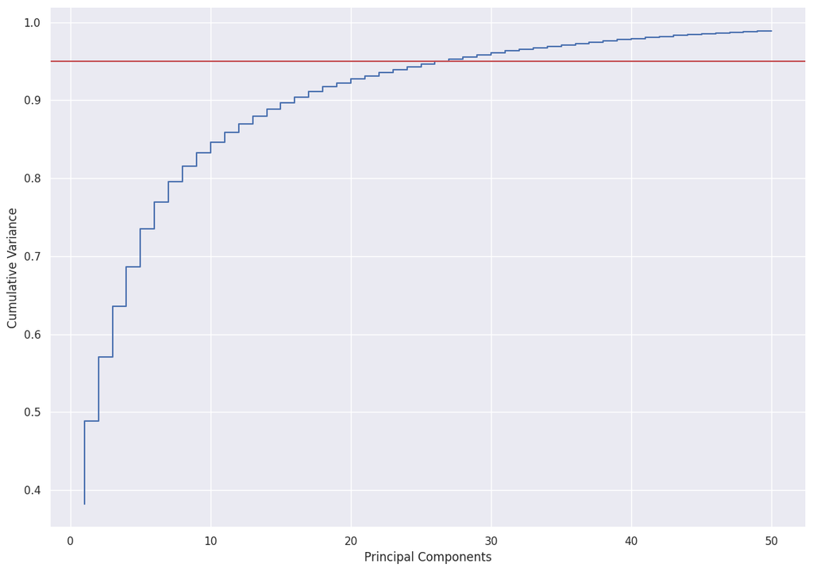

```python
pca = PCA(n_components=50)
pca.fit(X_train_over)

print(pca.components_)

plt.step(range(1,51),np.cumsum(pca.explained_variance_ratio_))
plt.ylabel('Cumulative Variance')
plt.xlabel('Principal Components')
plt.axhline(y = 0.95, color = 'r', linestyle = '-')
plt.tight_layout()
plt.show()
```

```python
pca = PCA(n_components=0.95)
pca.fit(X_train_over)
X_train_pca = pca.transform(X_train_over)
X_test_pca = pca.transform(X_test_over)
```

## Step 5: Design train and test basic machine learning classifiers

```python
# SVC regression

svc = SVC(kernel = 'rbf', probability=True)
model = svc.fit(X_train_pca, y_train_over)
y_test_predict_with_pca = model.predict(X_test_pca)

print("Accuracy on training set for SVC with PCA and OverSampling: {:.2f}".format(svc.score(X_train_pca, y_train_over)))
print("Accuracy on test set for SVC PCA and OverSampling: {:.2f}".format(svc.score(X_test_pca, y_test_over)))
print('f1 score for test data for SVC PCA and OverSampling: %.2f' %f1_score(y_test_over,y_test_predict_with_pca,average='micro'))
print('recall score for test data for SVC PCA and OverSampling: %.2f' %recall_score(y_test_over,y_test_predict_with_pca,average='micro'))
print('percision score for test data for SVC PCA and OverSampling: %.2f' %precision_score(y_test_over,y_test_predict_with_pca,average='micro'))

model = svc.fit(X_train_over, y_train_over)
y_test_predict_without_pca = model.predict(X_test_over)

print("Accuracy on training set for SVC with OverSampling only: {:.2f}".format(svc.score(X_train_over, y_train_over)))
print("Accuracy on test set for SVC with OverSampling only: {:.2f}".format(svc.score(X_test_over, y_test_over)))
print('f1 score for test data for SVC with OverSampling only: %.2f' %f1_score(y_test_over,y_test_predict_without_pca,average='micro'))
print('recall score for test data for SVC with OverSampling only: %.2f' %recall_score(y_test_over,y_test_predict_without_pca,average='micro'))
print('percision score for test data for SVC with OverSampling only: %.2f' %precision_score(y_test_over,y_test_predict_without_pca,average='micro'))

model = svc.fit(X_train, y_train)
y_test_predict_svc_org = model.predict(X_test)

print("Accuracy on training set for SVC with Original data: {:.2f}".format(svc.score(X_train, y_train)))
print("Accuracy on test set for SVC with Original data: {:.2f}".format(svc.score(X_test, y_test)))
print('f1 score for test data for SVC with Original data: %.2f' %f1_score(y_test,y_test_predict_svc_org,average='micro'))
print('recall score for test data for SVC with Original data: %.2f' %recall_score(y_test,y_test_predict_svc_org,average='micro'))
print('percision score for test data for SVC with Original data: %.2f' %precision_score(y_test,y_test_predict_svc_org,average='micro'))


param_grid = {'C': [0.1, 1, 10, 100, 1000],
              'gamma': [1, 0.1, 0.01, 0.001, 0.0001],
              'kernel': ['rbf','linear']}
grid = GridSearchCV(model,param_grid)
grid.fit(X_train, y_train)
y_test_predict_svc_org_tuned = grid.predict(X_test)

print("Accuracy on test set for tuned SVC with Original data: {:.2f}".format(accuracy_score(y_test, y_test_predict_svc_org_tuned)))
print('f1 score for test data for tuned SVC with Original data: %.2f' %f1_score(y_test,y_test_predict_svc_org_tuned,average='micro'))
print('recall score for test data for tuned SVC with Original data: %.2f' %recall_score(y_test,y_test_predict_svc_org_tuned,average='micro'))
print('percision score for test data for tuned SVC with Original data: %.2f' %precision_score(y_test,y_test_predict_svc_org_tuned,average='micro'))
```

```
Accuracy on training set for SVC with PCA and OverSampling: 0.73
Accuracy on test set for SVC PCA and OverSampling: 0.48
f1 score for test data for SVC PCA and OverSampling: 0.48
recall score for test data for SVC PCA and OverSampling: 0.48
percision score for test data for SVC PCA and OverSampling: 0.48
Accuracy on training set for SVC with OverSampling only: 0.71
Accuracy on test set for SVC with OverSampling only: 0.48
f1 score for test data for SVC with OverSampling only: 0.48
recall score for test data for SVC with OverSampling only: 0.48
percision score for test data for SVC with OverSampling only: 0.48
Accuracy on training set for SVC with Original data: 0.63
Accuracy on test set for SVC with Original data: 0.34
f1 score for test data for SVC with Original data: 0.34
recall score for test data for SVC with Original data: 0.34
percision score for test data for SVC with Original data: 0.34
Accuracy on test set for tuned SVC with Original data: 0.34
f1 score for test data for tuned SVC with Original data: 0.34
recall score for test data for tuned SVC with Original data: 0.34
percision score for test data for tuned SVC with Original data: 0.34
```

```python
knn_classifier = KNeighborsClassifier(n_neighbors = 8, weights = 'distance', metric = 'minkowski')
knn_classifier.fit(X_train_pca, y_train_over)
y_test_pred_knn_with_pca = knn_classifier.predict(X_test_pca)

print( 'Accuracy score for test data for KNN with OverSampling : %.4f' %accuracy_score(y_test_over,y_test_pred_knn_with_pca))
print('f1 score for test data for KNN with OverSampling: %.2f' %f1_score(y_test_over,y_test_pred_knn_with_pca,average='micro'))
print('recall score for test data for KNN with OverSampling: %.2f' %recall_score(y_test_over,y_test_pred_knn_with_pca,average='micro'))
print('percision score for test data for KNN with OverSampling: %.2f' %precision_score(y_test_over,y_test_pred_knn_with_pca,average='micro'))


knn_classifier.fit(X_train_over, y_train_over)
y_test_pred_knn_without_pca = knn_classifier.predict(X_test_over)

print( 'Accuracy score for test data for KNN with OverSampling only: %.4f' %accuracy_score(y_test_over,y_test_pred_knn_without_pca))
print('f1 score for test data for KNN with OverSampling only: %.2f' %f1_score(y_test_over,y_test_pred_knn_without_pca,average='micro'))
print('recall score for test data for KNN with OverSampling only: %.2f' %recall_score(y_test_over,y_test_pred_knn_without_pca,average='micro'))
print('percision score for test data for KNN with OverSampling only: %.2f' %precision_score(y_test_over,y_test_pred_knn_without_pca,average='micro'))


knn_classifier.fit(X_train, y_train)
y_test_pred_knn_org = knn_classifier.predict(X_test)

print( 'Accuracy score for test data for KNN with Original Data: %.4f' %accuracy_score(y_test,y_test_pred_knn_org))
print('f1 score for test data for KNN with Original Data: %.2f' %f1_score(y_test,y_test_pred_knn_org,average='micro'))
print('recall score for test data for KNN with Original Data: %.2f' %recall_score(y_test,y_test_pred_knn_org,average='micro'))
print('percision score for test data for KNN with Original Data: %.2f' %precision_score(y_test,y_test_pred_knn_org,average='micro'))

param_grid = { 'n_neighbors' : [2,4,5,6],
               'weights' : ['uniform','distance'],
               'metric' : ['minkowski','euclidean','manhattan']}

grid = GridSearchCV(knn_classifier,param_grid)
grid.fit(X_train, y_train)
y_test_pred_knn_org_tuned = grid.predict(X_test)
print( 'Accuracy score for test data for tuned KNN with Original Data: %.4f' %accuracy_score(y_test,y_test_pred_knn_org_tuned))
print('f1 score for test data for tuned KNN with Original Data: %.2f' %f1_score(y_test,y_test_pred_knn_org_tuned,average='micro'))
print('recall score for test data for tuned KNN with Original Data: %.2f' %recall_score(y_test,y_test_pred_knn_org_tuned,average='micro'))
print('percision score for test data for tuned KNN with Original Data: %.2f' %precision_score(y_test,y_test_pred_knn_org_tuned,average='micro'))
```

```
Accuracy score for test data for KNN with OverSampling : 0.4630
f1 score for test data for KNN with OverSampling: 0.46
recall score for test data for KNN with OverSampling: 0.46
percision score for test data for KNN with OverSampling: 0.46
Accuracy score for test data for KNN with OverSampling only: 0.4907
f1 score for test data for KNN with OverSampling only: 0.49
recall score for test data for KNN with OverSampling only: 0.49
percision score for test data for KNN with OverSampling only: 0.49
Accuracy score for test data for KNN with Original Data: 0.3529
f1 score for test data for KNN with Original Data: 0.35
recall score for test data for KNN with Original Data: 0.35
percision score for test data for KNN with Original Data: 0.35
Accuracy score for test data for tuned KNN with Original Data: 0.3529
f1 score for test data for tuned KNN with Original Data: 0.35
recall score for test data for tuned KNN with Original Data: 0.35
percision score for test data for tuned KNN with Original Data: 0.35
```

```python
forest = RandomForestClassifier(criterion='gini',
                                 n_estimators=10,
                                 random_state=1,
                                 n_jobs=2)

forest.fit(X_train_pca, y_train_over)
y_test_pred_rf_with_pca = forest.predict(X_test_pca)

print( 'Accuracy score for test data for RF with PCA and OverSampling: %.4f' %accuracy_score(y_test_over,y_test_pred_rf_with_pca))
print('f1 score for test data for RF with PCA and OverSampling: %.2f' %f1_score(y_test_over,y_test_pred_rf_with_pca,average='micro'))
print('recall score for test data for RF with PCA and OverSampling: %.2f' %recall_score(y_test_over,y_test_pred_rf_with_pca,average='micro'))
print('percision score for test data for RF with PCA and OverSampling: %.2f' %precision_score(y_test_over,y_test_pred_rf_with_pca,average='micro'))

forest.fit(X_train_over, y_train_over)
y_test_pred_rf_without_pca = forest.predict(X_test_over)

print( 'Accuracy score for test data for RF with OverSampling: %.4f' %accuracy_score(y_test_over,y_test_pred_rf_without_pca))
print('f1 score for test data for RF with OverSampling: %.2f' %f1_score(y_test_over,y_test_pred_rf_without_pca,average='micro'))
print('recall score for test data for RF with OverSampling: %.2f' %recall_score(y_test_over,y_test_pred_rf_without_pca,average='micro'))
print('percision score for test data for RF with OverSampling: %.2f' %precision_score(y_test_over,y_test_pred_rf_without_pca,average='micro'))


forest.fit(X_train, y_train)
y_test_pred_forest_org = forest.predict(X_test)

print( 'Accuracy score for test data for RF with Original Data: %.4f' %accuracy_score(y_test,y_test_pred_forest_org))
print('f1 score for test data for RF with Original Data: %.2f' %f1_score(y_test,y_test_pred_forest_org,average='micro'))
print('recall score for test data for RF with Original Data: %.2f' %recall_score(y_test,y_test_pred_forest_org,average='micro'))
print('percision score for test data for RF with Original Data: %.2f' %precision_score(y_test,y_test_pred_forest_org,average='micro'))



n_estimators = [1, 2, 4, 8, 16, 32, 64, 100, 200]
max_features = ['auto', 'sqrt']
max_depth = [int(x) for x in np.linspace(10, 110, num = 11)]
max_depth.append(None)
min_samples_split = [2, 5, 10]
min_samples_leaf = [1, 2, 4]
bootstrap = [True, False]
random_grid = {'n_estimators': n_estimators,
               'max_features': max_features,
               'max_depth': max_depth,
               'min_samples_split': min_samples_split,
               'min_samples_leaf': min_samples_leaf,
               'bootstrap': bootstrap}

rf_random = RandomizedSearchCV(estimator = forest, param_distributions = random_grid, n_iter = 100, cv = 3, verbose=2, random_state=42, n_jobs = -1)
rf_random.fit(X_train, y_train)
y_test_pred_forest_org_tuned = rf_random.predict(X_test)
print( 'Accuracy score for test data for tuned RF with Original Data: %.4f' %accuracy_score(y_test,y_test_pred_forest_org_tuned))
print('f1 score for test data for tuned RF with Original Data: %.2f' %f1_score(y_test,y_test_pred_forest_org_tuned,average='micro'))
print('recall score for test data for tuned RF with Original Data: %.2f' %recall_score(y_test,y_test_pred_forest_org_tuned,average='micro'))
print('percision score for test data for tuned RF with Original Data: %.2f' %precision_score(y_test,y_test_pred_forest_org_tuned,average='micro'))
```

```
Accuracy score for test data for RF with PCA and OverSampling: 0.4630
f1 score for test data for RF with PCA and OverSampling: 0.46
recall score for test data for RF with PCA and OverSampling: 0.46
percision score for test data for RF with PCA and OverSampling: 0.46
Accuracy score for test data for RF with OverSampling: 0.5185
f1 score for test data for RF with OverSampling: 0.52
recall score for test data for RF with OverSampling: 0.52
percision score for test data for RF with OverSampling: 0.52
Accuracy score for test data for RF with Original Data: 0.4000
f1 score for test data for RF with Original Data: 0.40
recall score for test data for RF with Original Data: 0.40
percision score for test data for RF with Original Data: 0.40
Fitting 3 folds for each of 100 candidates, totalling 300 fits
Accuracy score for test data for tuned RF with Original Data: 0.3294
f1 score for test data for tuned RF with Original Data: 0.33
recall score for test data for tuned RF with Original Data: 0.33
percision score for test data for tuned RF with Original Data: 0.33
```

```python
clf = DecisionTreeClassifier(criterion = 'gini')
clf = clf.fit(X_train_pca, y_train_over)
y_test_pred_dt_with_pca = clf.predict(X_test_pca)

print( 'Accuracy score for test data for dt with PCA and OverSampling: %.4f' %accuracy_score(y_test_over,y_test_pred_dt_with_pca))
print('f1 score for test data for dt with PCA and OverSampling: %.2f' %f1_score(y_test_over,y_test_pred_dt_with_pca,average='micro'))
print('recall score for test data for dt with PCA and OverSampling: %.2f' %recall_score(y_test_over,y_test_pred_dt_with_pca,average='micro'))
print('percision score for test data for dt with PCA and OverSampling: %.2f' %precision_score(y_test_over,y_test_pred_dt_with_pca,average='micro'))

clf.fit(X_train_over, y_train_over)
y_test_pred_dt_without_pca = clf.predict(X_test_over)

print( 'Accuracy score for test data for gb with OverSampling only: %.4f' %accuracy_score(y_test_over,y_test_pred_dt_without_pca))
print('f1 score for test data for gb without with OverSampling only: %.2f' %f1_score(y_test_over,y_test_pred_dt_without_pca,average='micro'))
print('recall score for test data for gb without with OverSampling only: %.2f' %recall_score(y_test_over,y_test_pred_dt_without_pca,average='micro'))
print('percision score for test data for gb without with OverSampling only: %.2f' %precision_score(y_test_over,y_test_pred_dt_without_pca,average='micro'))


clf.fit(X_train, y_train)
y_test_pred_clf_org = clf.predict(X_test)

print( 'Accuracy score for test data for DT with Original Data: %.4f' %accuracy_score(y_test,y_test_pred_clf_org))
print('f1 score for test data for DT with Original Data: %.2f' %f1_score(y_test,y_test_pred_clf_org,average='micro'))
print('recall score for test data for DT with Original Data: %.2f' %recall_score(y_test,y_test_pred_clf_org,average='micro'))
print('percision score for test data for DT with Original Data: %.2f' %precision_score(y_test,y_test_pred_clf_org,average='micro'))


param_grid = {
    'max_depth': [2, 3, 5, 10, 20],
    'min_samples_leaf': [5, 10, 20, 50, 100],
    'criterion': ["gini", "entropy"]
}

grid = GridSearchCV(clf,param_grid)
grid.fit(X_train, y_train)
y_test_pred_clf_org_tuned = grid.predict(X_test)
print( 'Accuracy score for test data for tuned DT with Original Data: %.4f' %accuracy_score(y_test,y_test_pred_clf_org_tuned))
print('f1 score for test data for tuned DT with Original Data: %.2f' %f1_score(y_test,y_test_pred_clf_org_tuned,average='micro'))
print('recall score for test data for tuned DT with Original Data: %.2f' %recall_score(y_test,y_test_pred_clf_org_tuned,average='micro'))
print('percision score for test data for tuned DT with Original Data: %.2f' %precision_score(y_test,y_test_pred_clf_org_tuned,average='micro'))
```

```
Accuracy score for test data for dt with PCA and OverSampling: 0.4722
f1 score for test data for dt with PCA and OverSampling: 0.47
recall score for test data for dt with PCA and OverSampling: 0.47
percision score for test data for dt with PCA and OverSampling: 0.47
Accuracy score for test data for gb with OverSampling only: 0.3889
f1 score for test data for gb without with OverSampling only: 0.39
recall score for test data for gb without with OverSampling only: 0.39
percision score for test data for gb without with OverSampling only: 0.39
Accuracy score for test data for DT with Original Data: 0.3529
f1 score for test data for DT with Original Data: 0.35
recall score for test data for DT with Original Data: 0.35
percision score for test data for DT with Original Data: 0.35
Accuracy score for test data for tuned DT with Original Data: 0.3412
f1 score for test data for tuned DT with Original Data: 0.34
recall score for test data for tuned DT with Original Data: 0.34
percision score for test data for tuned DT with Original Data: 0.34
```

```python
logreg = LogisticRegression(solver='lbfgs', multi_class='multinomial',random_state=16)
logreg.fit(X_train_pca, y_train_over)

y_test_pred_logreg_with_pca = logreg.predict(X_test_pca)

print( 'Accuracy score for test data for lr with PCA and OverSampling: %.4f' %accuracy_score(y_test_over,y_test_pred_logreg_with_pca))
print('f1 score for test data for lr with PCA and OverSampling: %.2f' %f1_score(y_test_over,y_test_pred_logreg_with_pca,average='micro'))
print('recall score for test data for lr with PCA and OverSampling: %.2f' %recall_score(y_test_over,y_test_pred_logreg_with_pca,average='micro'))
print('percision score for test data for lr with PCA and OverSampling: %.2f' %precision_score(y_test_over,y_test_pred_logreg_with_pca,average='micro'))

logreg.fit(X_train_over, y_train_over)
y_test_pred_logreg_without_pca = logreg.predict(X_test_over)

print( 'Accuracy score for test data for gb with OverSampling Only: %.4f' %accuracy_score(y_test_over,y_test_pred_dt_without_pca))
print('f1 score for test data for gb with OverSampling Only: %.2f' %f1_score(y_test_over,y_test_pred_dt_without_pca,average='micro'))
print('recall score for test data for gb with OverSampling Only: %.2f' %recall_score(y_test_over,y_test_pred_dt_without_pca,average='micro'))
print('percision score for test data for gb with OverSampling Only: %.2f' %precision_score(y_test_over,y_test_pred_dt_without_pca,average='micro'))


logreg.fit(X_train, y_train)
y_test_pred_logreg_org = logreg.predict(X_test)

print( 'Accuracy score for test data for lr with Original Data: %.4f' %accuracy_score(y_test,y_test_pred_logreg_org))
print('f1 score for test data for lr with Original Data: %.2f' %f1_score(y_test,y_test_pred_logreg_org,average='micro'))
print('recall score for test data for lr with Original Data: %.2f' %recall_score(y_test,y_test_pred_logreg_org,average='micro'))
print('percision score for test data for lr with Original Data: %.2f' %precision_score(y_test,y_test_pred_logreg_org,average='micro'))


param_grid = [
    {'penalty' : ['l1', 'l2', 'elasticnet', 'none'],
    'C' : np.logspace(-4, 4, 20),
    'solver' : ['lbfgs','newton-cg','liblinear','sag','saga'],
    'max_iter' :list(range(10,101,10))
    }
]

grid = GridSearchCV(logreg,param_grid)
grid.fit(X_train, y_train)
y_test_pred_logreg_org_tuned = grid.predict(X_test)
print( 'Accuracy score for test data for tuned lr with Original Data: %.4f' %accuracy_score(y_test,y_test_pred_logreg_org_tuned))
print('f1 score for test data for tuned lr with Original Data: %.2f' %f1_score(y_test,y_test_pred_logreg_org_tuned,average='micro'))
print('recall score for test data for tuned lr with Original Data: %.2f' %recall_score(y_test,y_test_pred_logreg_org_tuned,average='micro'))
print('percision score for test data for tuned lr with Original Data: %.2f' %precision_score(y_test,y_test_pred_logreg_org_tuned,average='micro'))
```

```
Accuracy score for test data for lr with PCA and OverSampling: 0.4907
f1 score for test data for lr with PCA and OverSampling: 0.49
recall score for test data for lr with PCA and OverSampling: 0.49
percision score for test data for lr with PCA and OverSampling: 0.49
Accuracy score for test data for gb with OverSampling Only: 0.3889
f1 score for test data for gb with OverSampling Only: 0.39
recall score for test data for gb with OverSampling Only: 0.39
percision score for test data for gb with OverSampling Only: 0.39
Accuracy score for test data for lr with Original Data: 0.3647
f1 score for test data for lr with Original Data: 0.36
recall score for test data for lr with Original Data: 0.36
percision score for test data for lr with Original Data: 0.36
Accuracy score for test data for tuned lr with Original Data: 0.3294
f1 score for test data for tuned lr with Original Data: 0.33
recall score for test data for tuned lr with Original Data: 0.33
percision score for test data for tuned lr with Original Data: 0.33
```

```python
ada_cls = AdaBoostClassifier(n_estimators=80, learning_rate=0.30)
ada_cls.fit(X_train_pca, y_train_over)
y_test_pred_ada_with_pca = ada_cls.predict(X_test_pca)

print( 'Accuracy score for test data for ada with PCA and OverSampling: %.4f' %accuracy_score(y_test_over,y_test_pred_ada_with_pca))
print('f1 score for test data for ada with PCA and OverSampling: %.2f' %f1_score(y_test_over,y_test_pred_ada_with_pca,average='micro'))
print('recall score for test data for ada with PCA and OverSampling: %.2f' %recall_score(y_test_over,y_test_pred_ada_with_pca,average='micro'))
print('percision score for test data for ada with PCA and OverSampling: %.2f' %precision_score(y_test_over,y_test_pred_ada_with_pca,average='micro'))

ada_cls.fit(X_train_over, y_train_over)
y_test_pred_ada_without_pca = ada_cls.predict(X_test_over)

print( 'Accuracy score for test data for ada with OverSampling: %.4f' %accuracy_score(y_test_over,y_test_pred_ada_without_pca))
print('f1 score for test data for ada with OverSampling: %.2f' %f1_score(y_test_over,y_test_pred_ada_without_pca,average='micro'))
print('recall score for test data for ada with OverSampling: %.2f' %recall_score(y_test_over,y_test_pred_ada_without_pca,average='micro'))
print('percision score for test data for ada with OverSampling: %.2f' %precision_score(y_test_over,y_test_pred_ada_without_pca,average='micro'))


ada_cls.fit(X_train, y_train)
y_test_pred_ada_org = ada_cls.predict(X_test)

print( 'Accuracy score for test data for ada with Original Data: %.4f' %accuracy_score(y_test,y_test_pred_ada_org))
print('f1 score for test data for ada with Original Data: %.2f' %f1_score(y_test,y_test_pred_ada_org,average='micro'))
print('recall score for test data for ada with Original Data: %.2f' %recall_score(y_test,y_test_pred_ada_org,average='micro'))
print('percision score for test data for ada with Original Data: %.2f' %precision_score(y_test,y_test_pred_ada_org,average='micro'))

parameters = {
    'n_estimators': [2, 3, 4, 5, 6, 7, 8, 9, 10, 11, 12, 20],
    'learning_rate': [(0.97 + x / 100) for x in range(0, 8)],
    'algorithm': ['SAMME', 'SAMME.R']
}

grid = GridSearchCV(ada_cls,parameters)
grid.fit(X_train, y_train)
y_test_pred_ada_org_tuned = grid.predict(X_test)
print( 'Accuracy score for test data for tuned ada with Original Data: %.4f' %accuracy_score(y_test,y_test_pred_ada_org_tuned))
print('f1 score for test data for tuned ada with Original Data: %.2f' %f1_score(y_test,y_test_pred_ada_org_tuned,average='micro'))
print('recall score for test data for tuned ada with Original Data: %.2f' %recall_score(y_test,y_test_pred_ada_org_tuned,average='micro'))
print('percision score for test data for tuned ada with Original Data: %.2f' %precision_score(y_test,y_test_pred_ada_org_tuned,average='micro'))
```

```
Accuracy score for test data for ada with PCA and OverSampling: 0.2778
f1 score for test data for ada with PCA and OverSampling: 0.28
recall score for test data for ada with PCA and OverSampling: 0.28
percision score for test data for ada with PCA and OverSampling: 0.28
Accuracy score for test data for ada with OverSampling: 0.3981
f1 score for test data for ada with OverSampling: 0.40
recall score for test data for ada with OverSampling: 0.40
percision score for test data for ada with OverSampling: 0.40
Accuracy score for test data for ada with Original Data: 0.3059
f1 score for test data for ada with Original Data: 0.31
recall score for test data for ada with Original Data: 0.31
percision score for test data for ada with Original Data: 0.31
Accuracy score for test data for tuned ada with Original Data: 0.3412
f1 score for test data for tuned ada with Original Data: 0.34
recall score for test data for tuned ada with Original Data: 0.34
percision score for test data for tuned ada with Original Data: 0.34
```

```python
gb_clf = GradientBoostingClassifier(n_estimators=20, learning_rate=0.1, max_features=2, max_depth=2, random_state=0)
gb_clf.fit(X_train_pca, y_train_over)
y_test_pred_gb_with_pca = gb_clf.predict(X_test_pca)

print( 'Accuracy score for test data for gb with PCA and OverSampling: %.4f' %accuracy_score(y_test_over,y_test_pred_gb_with_pca))
print('f1 score for test data for gb with PCA and OverSampling: %.2f' %f1_score(y_test_over,y_test_pred_gb_with_pca,average='micro'))
print('recall score for test data for gb with PCA and OverSampling: %.2f' %recall_score(y_test_over,y_test_pred_gb_with_pca,average='micro'))
print('percision score for test data for gb with PCA and OverSampling: %.2f' %precision_score(y_test_over,y_test_pred_gb_with_pca,average='micro'))

gb_clf.fit(X_train_over, y_train_over)
y_test_pred_gb_without_pca = gb_clf.predict(X_test_over)

print( 'Accuracy score for test data for gb with OverSampling: %.4f' %accuracy_score(y_test_over,y_test_pred_gb_without_pca))
print('f1 score for test data for gb with OverSampling: %.2f' %f1_score(y_test_over,y_test_pred_gb_without_pca,average='micro'))
print('recall score for test data for gb with OverSampling: %.2f' %recall_score(y_test_over,y_test_pred_gb_without_pca,average='micro'))
print('percision score for test data for gb with OverSampling: %.2f' %precision_score(y_test_over,y_test_pred_gb_without_pca,average='micro'))


gb_clf.fit(X_train, y_train)
y_test_pred_gb_org = gb_clf.predict(X_test)

print( 'Accuracy score for test data for gb with Original Data: %.4f' %accuracy_score(y_test,y_test_pred_gb_org))
print('f1 score for test data for gb with Original Data: %.2f' %f1_score(y_test,y_test_pred_gb_org,average='micro'))
print('recall score for test data for gb with Original Data: %.2f' %recall_score(y_test,y_test_pred_gb_org,average='micro'))
print('percision score for test data for gb with Original Data: %.2f' %precision_score(y_test,y_test_pred_gb_org,average='micro'))

learning_rate = [0.1,0.01,0.001]
n_estimators = [1, 2, 4, 8, 16, 32, 64, 100]
max_features = ['auto', 'sqrt']
max_depth = [2, 3, 5, 10, 20]
max_depth.append(None)
min_samples_split = [2, 5, 10]
min_samples_leaf = [1, 2, 4]
param_grid = {'n_estimators': n_estimators,
              'learning_rate':learning_rate,
               'max_features': max_features,
               'max_depth': max_depth,
               'min_samples_split': min_samples_split,
               'min_samples_leaf': min_samples_leaf}

grid = GridSearchCV(gb_clf,param_grid)
#grid.fit(X_train, y_train)
#y_test_pred_gb_org_tuned = grid.predict(X_test)
#print( 'Accuracy score for test data for tuned gb with Original Data: %.4f' %accuracy_score(y_test,y_test_pred_gb_org_tuned))
#print('f1 score for test data for tuned gb with Original Data: %.2f' %f1_score(y_test,y_test_pred_gb_org_tuned,average='micro'))
#print('recall score for test data for tuned gb with Original Data: %.2f' %recall_score(y_test,y_test_pred_gb_org_tuned,average='micro'))
#print('percision score for test data for tuned gb with Original Data: %.2f' %precision_score(y_test,y_test_pred_gb_org_tuned,average='micro'))
```

```
Accuracy score for test data for gb with PCA and OverSampling: 0.4722
f1 score for test data for gb with PCA and OverSampling: 0.47
recall score for test data for gb with PCA and OverSampling: 0.47
percision score for test data for gb with PCA and OverSampling: 0.47
Accuracy score for test data for gb with OverSampling: 0.4352
f1 score for test data for gb with OverSampling: 0.44
recall score for test data for gb with OverSampling: 0.44
percision score for test data for gb with OverSampling: 0.44
Accuracy score for test data for gb with Original Data: 0.2824
f1 score for test data for gb with Original Data: 0.28
recall score for test data for gb with Original Data: 0.28
percision score for test data for gb with Original Data: 0.28
```

Model is trained on below classifiers:

1. SVC
2. KNN
3. RandomForestClassifier
4. DecisionTreeClassifier
5. LogisticRegressionClassifier
6. AdaBoostClassifier
7. GradientBoostClassifier

These classifiers have been trained on

1. OverSampling + PCA enabled features
2. OverSampled Data
3. Original Data

# *Milestone 2*

## Step 1: Design, train and test Neural networks classifiers

### *Model 1: ANN*

```python
model1 = Sequential()

model1.add(Dense(15, input_dim=X_train.shape[1], activation='relu', kernel_initializer='he_uniform' ))
model1.add(Dropout(0.2))
model1.add(BatchNormalization())
model1.add(Dense(15, activation='relu', kernel_initializer='he_uniform'))
model1.add(Dropout(0.2))
model1.add(BatchNormalization())
model1.add(Dense(10, activation='relu', kernel_initializer='he_uniform'))
model1.add(Dropout(0.2))
model1.add(BatchNormalization())

model1.add(Dense(6, activation='softmax')) # Multilabel


opt = SGD(lr=0.0001, momentum=0.9)
model1.compile(loss='categorical_crossentropy', optimizer=opt, metrics=['categorical_accuracy'])


training_history1 = model1.fit(X_train, y_train_ohe, epochs=100, batch_size=8, verbose=1, validation_data=(X_test, y_test_ohe))
model1.summary()
```

```
Model: "sequential_6"
_________________________________________________________________
 Layer (type)                Output Shape              Param #
=================================================================
 dense_70 (Dense)            (None, 15)                1395

 dropout_34 (Dropout)        (None, 15)                0

 batch_normalization_8 (Batc  (None, 15)               60
 hNormalization)

 dense_71 (Dense)            (None, 15)                240

 dropout_35 (Dropout)        (None, 15)                0

 batch_normalization_9 (Batc  (None, 15)               60
 hNormalization)

 dense_72 (Dense)            (None, 10)                160

 dropout_36 (Dropout)        (None, 10)                0

 batch_normalization_10 (Bat  (None, 10)               40
 chNormalization)

 dense_73 (Dense)            (None, 6)                 66

=================================================================
Total params: 2,021
Trainable params: 1,941
Non-trainable params: 80
_________________________________________________________________
```

```python
_, train_accuracy = model1.evaluate(X_train, y_train_ohe, batch_size=8, verbose=0)
_, test_accuracy = model1.evaluate(X_test, y_test_ohe, batch_size=8, verbose=0)

print('Train accuracy: %.2f' % (train_accuracy*100))
print('Test accuracy: %.2f' % (test_accuracy*100))
```

```
Train accuracy: 45.13
Test accuracy: 24.71
```

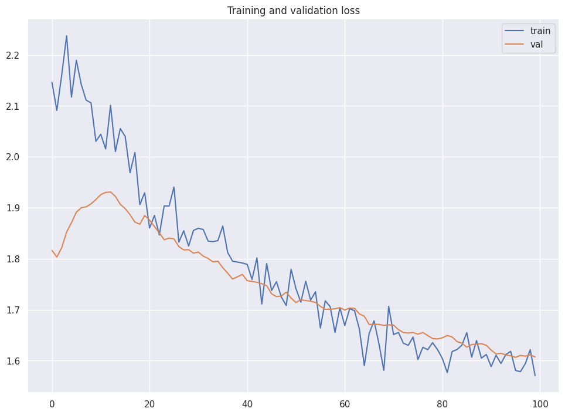

```python
epochs = range(len(training_history1.history['loss']))
plt.plot(epochs, training_history1.history['loss'], label = 'train')
plt.plot(epochs, training_history1.history['val_loss'], label = 'val')
plt.legend(loc = 'upper right')
plt.title ('Training and validation loss')
```

*Train accuracy: 45.13 and Test accuracy: 24.71 . Model is a good fit.*

```python
model1 = Sequential()
model1.add(Dense(15, input_dim=X_train.shape[1], activation='relu', kernel_initializer='he_uniform' ))
model1.add(Dense(15, activation='relu', kernel_initializer='he_uniform'))
model1.add(Dense(10, activation='relu', kernel_initializer='he_uniform'))
model1.add(Dense(6, activation='softmax')) # Multilabel
opt = Adam(lr=0.0001)
model1.compile(loss='categorical_crossentropy', optimizer=opt, metrics=['categorical_accuracy'])


training_history1 = model1.fit(X_train, y_train_ohe, epochs=200, batch_size=8, verbose=1, validation_data=(X_test, y_test_ohe))
model1.summary()
```

```
Model: "sequential_7"
_________________________________________________________________
 Layer (type)                Output Shape              Param #
=================================================================
 dense_74 (Dense)            (None, 15)                1395

 dense_75 (Dense)            (None, 15)                240

 dense_76 (Dense)            (None, 10)                160

 dense_77 (Dense)            (None, 6)                 66

=================================================================
Total params: 1,861
Trainable params: 1,861
Non-trainable params: 0
_________________________________________________________________
```

```python
_, train_accuracy = model1.evaluate(X_train, y_train_ohe, batch_size=8, verbose=0)
_, test_accuracy = model1.evaluate(X_test, y_test_ohe, batch_size=8, verbose=0)

print('Train accuracy: %.2f' % (train_accuracy*100))
print('Test accuracy: %.2f' % (test_accuracy*100))
```

```
Train accuracy: 63.72
Test accuracy: 34.12
```

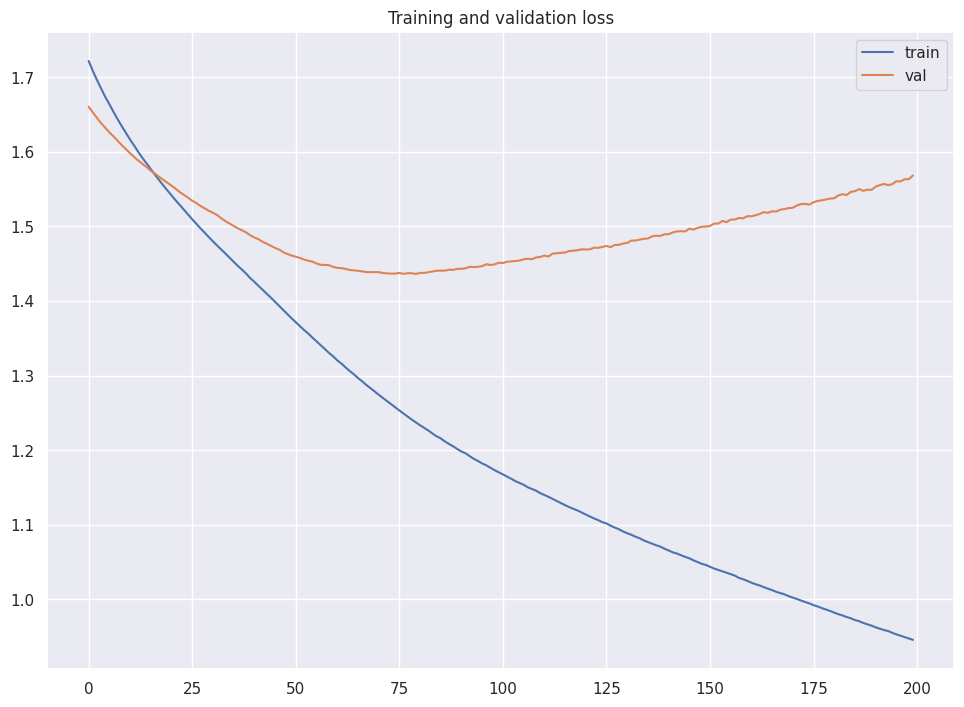

```python
epochs = range(len(training_history1.history['loss']))
plt.plot(epochs, training_history1.history['loss'], label = 'train')
plt.plot(epochs, training_history1.history['val_loss'], label = 'val')
plt.legend(loc = 'upper right')
plt.title ('Training and validation loss')
```

Train accuracy: 63.72 and Test accuracy: 34.12. Model is overfit as more loss validation.

### *Model 2: ANN with RBF*

```python
class RBFLayer(Layer):
    def __init__(self, units, gamma, **kwargs):
        super(RBFLayer, self).__init__(**kwargs)
        self.units = units
        self.gamma = K.cast_to_floatx(gamma)

    def build(self, input_shape):
#         print(input_shape)
#         print(self.units)
        self.mu = self.add_weight(name='mu',
                                  shape=(int(input_shape[1]), self.units),
                                  initializer='uniform',
                                  trainable=True)
        super(RBFLayer, self).build(input_shape)

    def call(self, inputs):
        diff = K.expand_dims(inputs) - self.mu
        l2 = K.sum(K.pow(diff, 2), axis=1)
        res = K.exp(-1 * self.gamma * l2)
        return res

    def compute_output_shape(self, input_shape):
        return (input_shape[0], self.units)
```

```python
model2 = Sequential()

model2.add(Dense(15, input_dim=X_train.shape[1], activation='relu', kernel_initializer='he_uniform' ))
model2.add(Dense(15, activation='relu', kernel_initializer='he_uniform'))
model2.add(Dropout(0.2))
model2.add(BatchNormalization())
model2.add(Dense(15, activation='relu', kernel_initializer='he_uniform'))
model2.add(RBFLayer(15, 0.5))
model2.add(Dropout(0.5))
model2.add(Dense(6, activation='softmax')) # Multilabel


opt = SGD(lr=0.001, momentum=0.9)
model2.compile(loss='categorical_crossentropy', optimizer=opt, metrics=['categorical_accuracy'])


training_history2 = model2.fit(X_train, y_train_ohe, epochs=100, batch_size=8, verbose=1, validation_data=(X_test, y_test_ohe))
model2.summary()
```

```
Model: "sequential_8"
_________________________________________________________________
 Layer (type)                Output Shape              Param #
=================================================================
 dense_78 (Dense)            (None, 15)                1395

 dense_79 (Dense)            (None, 15)                240

 dropout_37 (Dropout)        (None, 15)                0

 batch_normalization_11 (Bat  (None, 15)               60
 chNormalization)

 dense_80 (Dense)            (None, 15)                240

 rbf_layer_3 (RBFLayer)      (None, 15)                225

 dropout_38 (Dropout)        (None, 15)                0

 dense_81 (Dense)            (None, 6)                 96

=================================================================
Total params: 2,256
Trainable params: 2,226
Non-trainable params: 30
_________________________________________________________________
```

```python
_, train_accuracy = model2.evaluate(X_train, y_train_ohe, batch_size=8, verbose=0)
_, test_accuracy = model2.evaluate(X_test, y_test_ohe, batch_size=8, verbose=0)

print('Train accuracy: %.2f' % (train_accuracy*100))
print('Test accuracy: %.2f' % (test_accuracy*100))
```

```
Train accuracy: 43.95
Test accuracy: 28.24
```

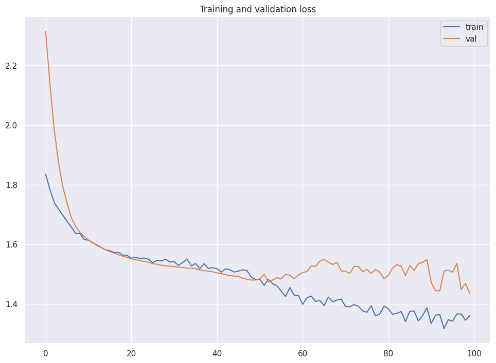

```python
epochs = range(len(training_history2.history['loss']))
plt.plot(epochs, training_history2.history['loss'], label = 'train')
plt.plot(epochs, training_history2.history['val_loss'], label = 'val')
plt.legend(loc = 'upper right')
plt.title ('Training and validation loss')
```

*Train accuracy: 43.95 and Test accuracy: 28.24. Model is a good fit*

```python
model2 = Sequential()

model2.add(Dense(15, input_dim=X_train.shape[1], activation='relu', kernel_initializer='he_uniform' ))
model2.add(Dense(15, activation='relu', kernel_initializer='he_uniform'))
model2.add(Dense(15, activation='relu', kernel_initializer='he_uniform'))
model2.add(RBFLayer(15, 0.5))
model2.add(Dense(6, activation='softmax')) # Multilabel


opt = Adam(lr=0.0001)
model2.compile(loss='categorical_crossentropy', optimizer=opt, metrics=['categorical_accuracy'])


training_history2 = model2.fit(X_train, y_train_ohe, epochs=200, batch_size=8, verbose=1, validation_data=(X_test, y_test_ohe))
model2.summary()
```

```
Model: "sequential_9"
_________________________________________________________________
 Layer (type)                Output Shape              Param #
=================================================================
 dense_82 (Dense)            (None, 15)                1395

 dense_83 (Dense)            (None, 15)                240

 dense_84 (Dense)            (None, 15)                240

 rbf_layer_4 (RBFLayer)      (None, 15)                225

 dense_85 (Dense)            (None, 6)                 96

=================================================================
Total params: 2,196
Trainable params: 2,196
Non-trainable params: 0
_________________________________________________________________
```

```python
_, train_accuracy = model2.evaluate(X_train, y_train_ohe, batch_size=8, verbose=0)
_, test_accuracy = model2.evaluate(X_test, y_test_ohe, batch_size=8, verbose=0)

print('Train accuracy: %.2f' % (train_accuracy*100))
print('Test accuracy: %.2f' % (test_accuracy*100))
```

```
Train accuracy: 61.65
Test accuracy: 28.24
```

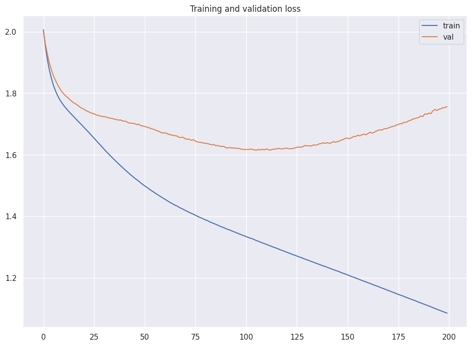

```python
epochs = range(len(training_history2.history['loss']))
plt.plot(epochs, training_history2.history['loss'], label = 'train')
plt.plot(epochs, training_history2.history['val_loss'], label = 'val')
plt.legend(loc = 'upper right')
plt.title ('Training and validation loss')
```

### Step 2: Design, train and test RNN or LSTM classifiers

```python
tokenizer = Tokenizer(split=' ')
X_text_train, X_text_test, y_text_train, y_text_test = train_test_split(X_text, y_ohe, test_size = 0.20, random_state = 42)
tokenizer.fit_on_texts(X_text_train.values)
X_text_train = tokenizer.texts_to_sequences(X_text_train)
X_text_test = tokenizer.texts_to_sequences(X_text_test)
maxlen = 100
X_text_train = pad_sequences(X_text_train, padding='post', maxlen=maxlen)
X_text_test = pad_sequences(X_text_test, padding='post', maxlen=maxlen)
```

```python
print('Found %s word vectors.' % len(embeddings_index))
vocab_size = len(tokenizer.word_index) + 1
print("vocab_size:", vocab_size)
```

```
Found 400000 word vectors.
vocab_size: 2148
```

```python
embedding_size = 32


embedding_matrix = np.zeros((vocab_size, embedding_size))

for word, index in tokenizer.word_index.items():
    embedding_vector = embeddings_index.get(word)
    if embedding_vector is not None:
        embedding_matrix[index] = embedding_vector[0:embedding_size]
```

### *Model 1: Bidirectional with LSTM*

```python
deep_inputs = Input(shape=(maxlen,))
embedding_layer = Embedding(vocab_size, embedding_size, weights=[embedding_matrix], trainable=False)(deep_inputs)
LSTM_Layer = Bidirectional(LSTM(10, return_sequences = True))(embedding_layer)
max_pool_layer_1 = GlobalMaxPool1D()(LSTM_Layer)
#drop_out_layer_1 = Dropout(0.2, input_shape = (10,))(max_pool_layer_1)
dense_layer_1 = Dense(10, activation = 'relu')(max_pool_layer_1)
#drop_out_layer_2 = Dropout(0.2, input_shape = (10,))(dense_layer_1)
dense_layer_6 = Dense(15, activation = 'relu')(dense_layer_1 )
#drop_out_layer_6 = Dropout(0.2, input_shape = (15,))(dense_layer_6)
dense_layer_2 = Dense(20, activation = 'relu')(dense_layer_6)
#drop_out_layer_3 = Dropout(0.1, input_shape = (20,))(dense_layer_2)

#dense_layer_3 = Dense(128, activation = 'relu')(dense_layer_2)
#drop_out_layer_4 = Dropout(0.2, input_shape = (128,))(dense_layer_3)

#dense_layer_4 = Dense(128, activation = 'relu')(dense_layer_3)
#drop_out_layer_5 = Dropout(0.1, input_shape = (10,))(dense_layer_4)

dense_layer_5 = Dense(6, activation='softmax')(dense_layer_2)

model3 = Model(inputs=deep_inputs, outputs=dense_layer_5)


opt = SGD(lr=0.0001, momentum=0.9)
model3.compile(loss='categorical_crossentropy', optimizer=opt, metrics=['acc'])
```

```python
print(model3.summary())
```

```
Model: "model_15"
_________________________________________________________________
 Layer (type)                Output Shape              Param #
=================================================================
 input_16 (InputLayer)       [(None, 100)]             0

 embedding_15 (Embedding)    (None, 100, 32)           68736

 bidirectional_5 (Bidirectio  (None, 100, 20)          3440
 nal)

 global_max_pooling1d_9 (Glo  (None, 20)               0
 balMaxPooling1D)

 dense_86 (Dense)            (None, 10)                210

 dense_87 (Dense)            (None, 15)                165

 dense_88 (Dense)            (None, 20)                320

 dense_89 (Dense)            (None, 6)                 126

=================================================================
Total params: 72,997
Trainable params: 4,261
Non-trainable params: 68,736
_________________________________________________________________
None
```

```python
training_history3 = model3.fit(X_text_train, y_text_train, epochs=100, batch_size=8, verbose=1, validation_data=(X_text_test, y_text_test))
```

```python
_, train_accuracy = model3.evaluate(X_text_train, y_text_train, batch_size=8, verbose=0)
_, test_accuracy = model3.evaluate(X_text_test, y_text_test, batch_size=8, verbose=0)

print('Train accuracy: %.2f' % (train_accuracy*100))
print('Test accuracy: %.2f' % (test_accuracy*100))
```

```
Train accuracy: 34.81
Test accuracy: 29.41
```

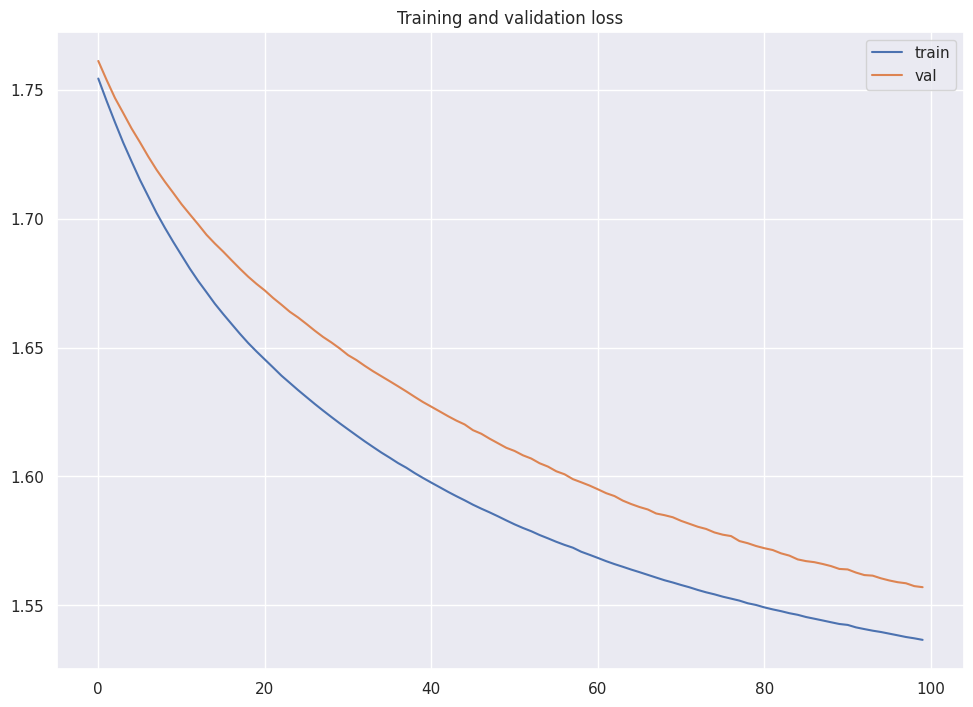

```python
epochs = range(len(training_history3.history['loss']))
plt.plot(epochs, training_history3.history['loss'], label = 'train')
plt.plot(epochs, training_history3.history['val_loss'], label = 'val')
plt.legend(loc = 'upper right')
plt.title ('Training and validation loss')
```

*Train accuracy: 34.81 and Test accuracy: 29.41. Model is not suffering overfitting condition.*

```python
deep_inputs = Input(shape=(maxlen,))
embedding_layer = Embedding(vocab_size, embedding_size, weights=[embedding_matrix], trainable=False)(deep_inputs)
LSTM_Layer = Bidirectional(LSTM(10, return_sequences = True))(embedding_layer)
max_pool_layer_1 = GlobalMaxPool1D()(LSTM_Layer)
#drop_out_layer_1 = Dropout(0.2, input_shape = (10,))(max_pool_layer_1)
dense_layer_1 = Dense(10, activation = 'relu')(max_pool_layer_1)
#drop_out_layer_2 = Dropout(0.2, input_shape = (10,))(dense_layer_1)
dense_layer_6 = Dense(15, activation = 'relu')(dense_layer_1 )
#drop_out_layer_6 = Dropout(0.2, input_shape = (15,))(dense_layer_6)
dense_layer_2 = Dense(20, activation = 'relu')(dense_layer_6)
#drop_out_layer_3 = Dropout(0.1, input_shape = (20,))(dense_layer_2)

dense_layer_5 = Dense(6, activation='softmax')(dense_layer_2)

model3 = Model(inputs=deep_inputs, outputs=dense_layer_5)


opt = Adam(lr=0.0001)
model3.compile(loss='categorical_crossentropy', optimizer=opt, metrics=['acc'])

training_history3 = model3.fit(X_text_train, y_text_train, epochs=150, batch_size=8, verbose=1, validation_data=(X_text_test, y_text_test))
```

```python
_, train_accuracy = model3.evaluate(X_text_train, y_text_train, batch_size=8, verbose=0)
_, test_accuracy = model3.evaluate(X_text_test, y_text_test, batch_size=8, verbose=0)

print('Train accuracy: %.2f' % (train_accuracy*100))
print('Test accuracy: %.2f' % (test_accuracy*100))
```

```
Train accuracy: 57.82
Test accuracy: 31.76
```

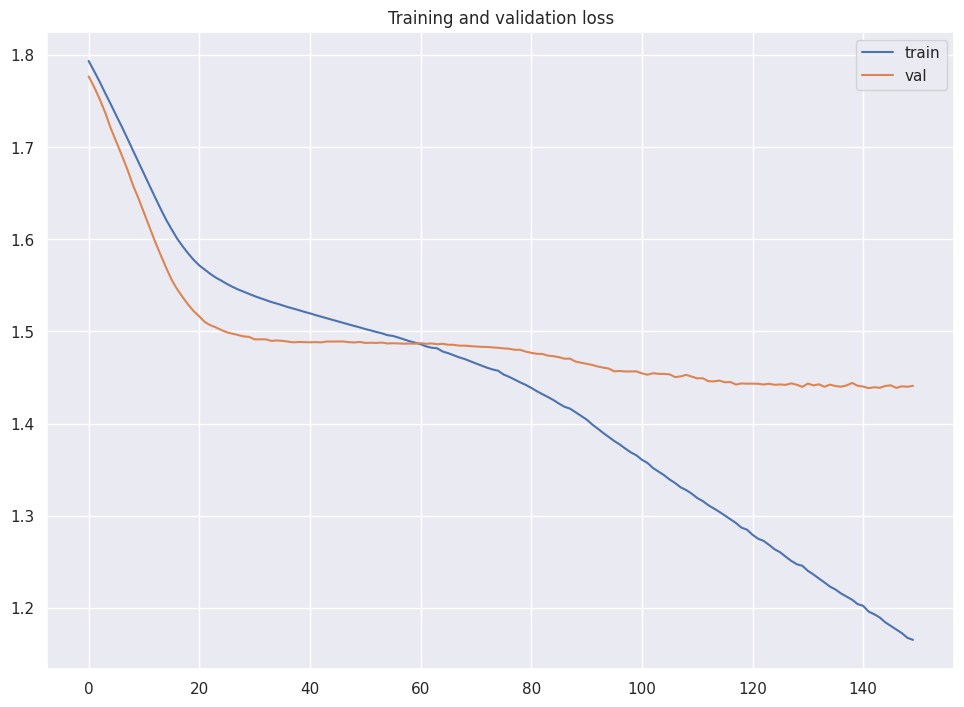

```python
epochs = range(len(training_history3.history['loss']))
plt.plot(epochs, training_history3.history['loss'], label = 'train')
plt.plot(epochs, training_history3.history['val_loss'], label = 'val')
plt.legend(loc = 'upper right')
plt.title ('Training and validation loss')
```

Train accuracy: 57.82 and Test accuracy: 31.76. Model is suffering a bit of divergence between train and test.

### *Model 2: LSTM*

```python
deep_inputs = Input(shape=(maxlen,))
embedding_layer = Embedding(vocab_size, embedding_size, weights=[embedding_matrix], trainable=True)(deep_inputs)
LSTM_Layer = LSTM(32, return_sequences = False)(embedding_layer)
drop_out_layer_1 = Dropout(0.2, input_shape = (32,))(LSTM_Layer)
dense_layer_1 = Dense(32, activation = 'relu')(drop_out_layer_1)
drop_out_layer_2 = Dropout(0.2, input_shape = (32,))(dense_layer_1)
dense_layer_6 = Dense(64, activation = 'relu')(drop_out_layer_2)
drop_out_layer_6 = Dropout(0.2, input_shape = (64,))(dense_layer_6)
#dense_layer_2 = Dense(64, activation = 'relu')(drop_out_layer_6)
#drop_out_layer_3 = Dropout(0.2, input_shape = (64,))(dense_layer_2)

#dense_layer_3 = Dense(128, activation = 'relu')(drop_out_layer_3)
#drop_out_layer_4 = Dropout(0.2, input_shape = (128,))(dense_layer_3)

dense_layer_5 = Dense(6, activation='softmax')(drop_out_layer_6)

model4 = Model(inputs=deep_inputs, outputs=dense_layer_5)


opt = SGD(lr=0.0001, momentum=0.9)
model4.compile(loss='categorical_crossentropy', optimizer=opt, metrics=['acc'])
```

```python
training_history4 = model4.fit(X_text_train, y_text_train, epochs=100, batch_size=8, verbose=1, validation_data=(X_text_test, y_text_test))
```

```python
_, train_accuracy = model4.evaluate(X_text_train, y_text_train, batch_size=8, verbose=0)
_, test_accuracy = model4.evaluate(X_text_test, y_text_test, batch_size=8, verbose=0)

print('Train accuracy: %.2f' % (train_accuracy*100))
print('Test accuracy: %.2f' % (test_accuracy*100))
```

```
Train accuracy: 34.81
Test accuracy: 29.41
```

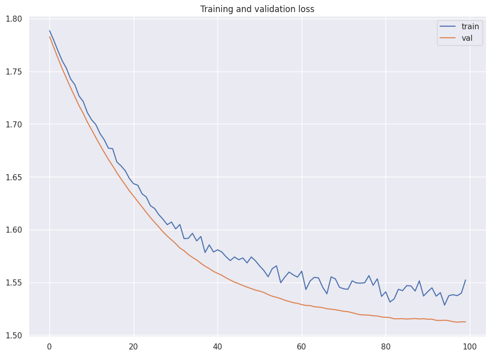

```python
epochs = range(len(training_history4.history['loss']))
plt.plot(epochs, training_history4.history['loss'], label = 'train')
plt.plot(epochs, training_history4.history['val_loss'], label = 'val')
plt.legend(loc = 'upper right')
plt.title ('Training and validation loss')
```

*Train accuracy: 34.81 and Test accuracy: 29.41. Model is not suffering overfitting condition.*

```python
deep_inputs = Input(shape=(maxlen,))
embedding_layer = Embedding(vocab_size, embedding_size, weights=[embedding_matrix], trainable=True)(deep_inputs)
LSTM_Layer = LSTM(32, return_sequences = False)(embedding_layer)
#drop_out_layer_1 = Dropout(0.2, input_shape = (32,))(LSTM_Layer)
dense_layer_1 = Dense(32, activation = 'relu')(LSTM_Layer)
#drop_out_layer_2 = Dropout(0.2, input_shape = (32,))(dense_layer_1)
dense_layer_6 = Dense(64, activation = 'relu')(dense_layer_1)
#drop_out_layer_6 = Dropout(0.2, input_shape = (64,))(dense_layer_6)
#dense_layer_2 = Dense(64, activation = 'relu')(drop_out_layer_6)
#drop_out_layer_3 = Dropout(0.2, input_shape = (64,))(dense_layer_2)

#dense_layer_3 = Dense(128, activation = 'relu')(drop_out_layer_3)
#drop_out_layer_4 = Dropout(0.2, input_shape = (128,))(dense_layer_3)

dense_layer_5 = Dense(6, activation='softmax')(dense_layer_6)

model4 = Model(inputs=deep_inputs, outputs=dense_layer_5)


opt = Adam(lr=0.0001)
model4.compile(loss='categorical_crossentropy', optimizer=opt, metrics=['acc'])

training_history4 = model4.fit(X_text_train, y_text_train, epochs=100, batch_size=8, verbose=1, validation_data=(X_text_test, y_text_test))
```

```python
_, train_accuracy = model4.evaluate(X_text_train, y_text_train, batch_size=8, verbose=0)
_, test_accuracy = model4.evaluate(X_text_test, y_text_test, batch_size=8, verbose=0)

print('Train accuracy: %.2f' % (train_accuracy*100))
print('Test accuracy: %.2f' % (test_accuracy*100))
```

```
Train accuracy: 44.25
Test accuracy: 30.59
```

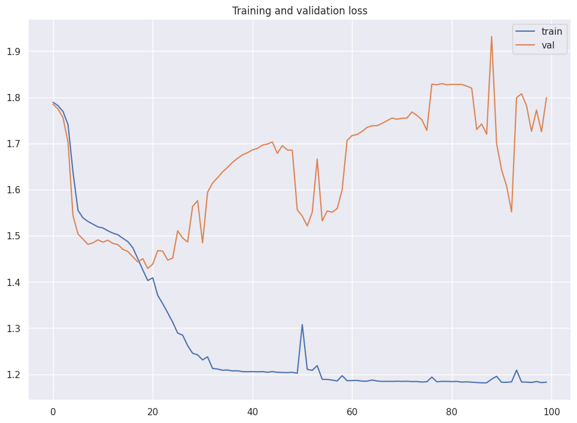

```python
epochs = range(len(training_history4.history['loss']))
plt.plot(epochs, training_history4.history['loss'], label = 'train')
plt.plot(epochs, training_history4.history['val_loss'], label = 'val')
plt.legend(loc = 'upper right')
plt.title ('Training and validation loss')
```

### *Model 3: LSTM multiple layer*

```python
deep_inputs = Input(shape=(maxlen,))
embedding_layer = Embedding(vocab_size, embedding_size, weights=[embedding_matrix], trainable=False)(deep_inputs)
LSTM_Layer = LSTM(32, return_sequences = True)(embedding_layer)

LSTM_Layer_2 = LSTM(32, return_sequences = True)(LSTM_Layer)
max_pool_layer_2 = GlobalMaxPool1D()(LSTM_Layer_2)
#drop_out_layer_1 = Dropout(0.1, input_shape = (256,))(max_pool_layer_2)
#dense_layer_1 = Dense(256, activation = 'relu')(drop_out_layer_1)
drop_out_layer_2 = Dropout(0.2, input_shape = (32,))(max_pool_layer_2)
dense_layer_6 = Dense(64, activation = 'relu')(drop_out_layer_2)
drop_out_layer_6 = Dropout(0.2, input_shape = (64,))(dense_layer_6)
#dense_layer_2 = Dense(64, activation = 'relu')(drop_out_layer_6)
#drop_out_layer_3 = Dropout(0.3, input_shape = (64,))(dense_layer_2)

#dense_layer_3 = Dense(32, activation = 'relu')(dense_layer_2)
#drop_out_layer_4 = Dropout(0.3, input_shape = (32,))(dense_layer_3)

#dense_layer_4 = Dense(10, activation = 'relu')(dense_layer_3)
#drop_out_layer_5 = Dropout(0.1, input_shape = (10,))(dense_layer_4)

dense_layer_5 = Dense(6, activation='softmax')(drop_out_layer_6)

model5 = Model(inputs=deep_inputs, outputs=dense_layer_5)


opt = SGD(lr=0.0001, momentum=0.9)
model5.compile(loss='categorical_crossentropy', optimizer=opt, metrics=['acc'])
training_history5 = model5.fit(X_text_train, y_text_train, epochs=100, batch_size=8, verbose=1, validation_data=(X_text_test, y_text_test))
_, train_accuracy = model5.evaluate(X_text_train, y_text_train, batch_size=8, verbose=0)
_, test_accuracy = model5.evaluate(X_text_test, y_text_test, batch_size=8, verbose=0)

print('Train accuracy: %.2f' % (train_accuracy*100))
print('Test accuracy: %.2f' % (test_accuracy*100))
```

```
Train accuracy: 34.81
Test accuracy: 29.41
```

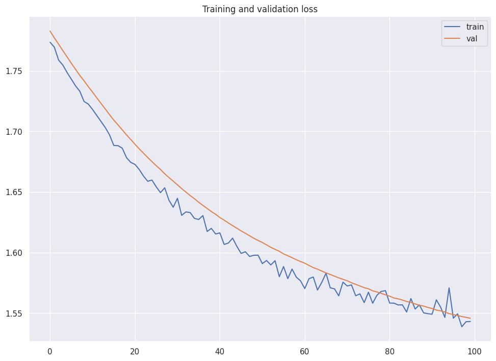

```python
epochs = range(len(training_history5.history['loss']))
plt.plot(epochs, training_history5.history['loss'], label = 'train')
plt.plot(epochs, training_history5.history['val_loss'], label = 'val')
plt.legend(loc = 'upper right')
plt.title ('Training and validation loss')
```

*Train accuracy: 34.81 and Test accuracy: 29.41. Model is not suffering overfitting condition.*

```python
deep_inputs = Input(shape=(maxlen,))
embedding_layer = Embedding(vocab_size, embedding_size, weights=[embedding_matrix], trainable=False)(deep_inputs)
LSTM_Layer = LSTM(32, return_sequences = True)(embedding_layer)

LSTM_Layer_2 = LSTM(32, return_sequences = True)(LSTM_Layer)
max_pool_layer_2 = GlobalMaxPool1D()(LSTM_Layer_2)
#drop_out_layer_1 = Dropout(0.1, input_shape = (256,))(max_pool_layer_2)
#dense_layer_1 = Dense(256, activation = 'relu')(drop_out_layer_1)
#drop_out_layer_2 = Dropout(0.2, input_shape = (32,))(max_pool_layer_2)
dense_layer_6 = Dense(64, activation = 'relu')(max_pool_layer_2)
#drop_out_layer_6 = Dropout(0.2, input_shape = (64,))(dense_layer_6)
#dense_layer_2 = Dense(64, activation = 'relu')(drop_out_layer_6)
#drop_out_layer_3 = Dropout(0.3, input_shape = (64,))(dense_layer_2)

#dense_layer_3 = Dense(32, activation = 'relu')(dense_layer_2)
#drop_out_layer_4 = Dropout(0.3, input_shape = (32,))(dense_layer_3)

#dense_layer_4 = Dense(10, activation = 'relu')(dense_layer_3)
#drop_out_layer_5 = Dropout(0.1, input_shape = (10,))(dense_layer_4)

dense_layer_5 = Dense(6, activation='softmax')(dense_layer_6)

model5 = Model(inputs=deep_inputs, outputs=dense_layer_5)


opt = Adam(lr=0.0001)
model5.compile(loss='categorical_crossentropy', optimizer=opt, metrics=['acc'])
training_history5 = model5.fit(X_text_train, y_text_train, epochs=150, batch_size=8, verbose=1, validation_data=(X_text_test, y_text_test))
_, train_accuracy = model5.evaluate(X_text_train, y_text_train, batch_size=8, verbose=0)
_, test_accuracy = model5.evaluate(X_text_test, y_text_test, batch_size=8, verbose=0)

print('Train accuracy: %.2f' % (train_accuracy*100))
print('Test accuracy: %.2f' % (test_accuracy*100))
```

```
Train accuracy: 69.03
Test accuracy: 38.82
```

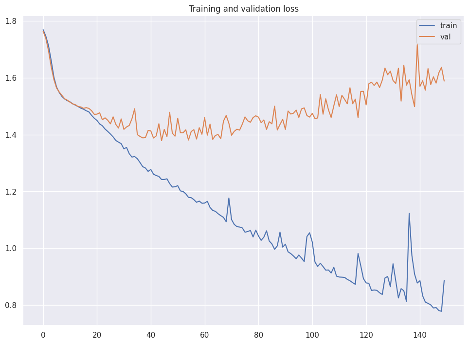

```python
epochs = range(len(training_history5.history['loss']))
plt.plot(epochs, training_history5.history['loss'], label = 'train')
plt.plot(epochs, training_history5.history['val_loss'], label = 'val')
plt.legend(loc = 'upper right')
plt.title ('Training and validation loss')
```

*Train accuracy: 69.03 and Test accuracy: 38.82 . Model is overfit*

Below Neural networks got trained, and accuracy comes out to be as:

**Using SGD optimizer:**

1. Artificial Neural Networks -Train accuracy: 45.13,Test accuracy: 24.71 .
2. Artificial Neural Networks with RBF - Train accuracy: 43.95, Test accuracy: 28.24 .
3. LSTM with BiDirectional - Train accuracy: 34.81, Test accuracy: 29.41
4. LSTM - Train accuracy: 34.81, Test accuracy: 29.41
5. LSTM with multiple layer - Train accuracy: 34.81 Test accuracy: 29.41

**Using Adam optimizer:**

1. Artificial Neural Networks -Train accuracy: Train accuracy: 63.72, Test accuracy: 34.12
2. Artificial Neural Networks with RBF - Train accuracy: 61.65, Test accuracy: 28.24 .
3. LSTM with BiDirectional -Train accuracy: 57.82, Test accuracy: 31.76 .
4. LSTM - Train accuracy: 44.25, Test accuracy: 30.59
5. LSTM with multiple layer - Train accuracy:69.03, Test accuracy: 38.82 .

```python
Pkl_Filename = "Pickle_Model.pkl"

with open(Pkl_Filename, 'wb') as file:
    pickle.dump(logreg, file)
```